# Meta-analysis: Relationship between procedural learning and language and literacy

Cátia Margarida Oliveira[^1], Marianna E. Hayiou-Thomas, Lisa Henderson; University of York

This file is licensed under the terms and conditions of the CC-BY 4.0 INTERNATIONAL  
for details on the license, see  
http://creativecommons.org/licenses/by/4.0/

# Import functions

```r
source("utils.R")
```

# Import libraries

```r
MAc <- "https://cran.r-project.org/src/contrib/Archive/MAc/MAc_1.1.tar.gz"
install.packages(MAc, repos=NULL, type="source")

listOfPackages <- c("readxl", "rmarkdown","robumeta","SciViews","PublicationBias","clubSandwich",
                    "metafor","tidyverse","readxl", "stats","dplyr", "here", "stargazer", "gridExtra", "purrr")
ipak(listOfPackages)
```

```
##          readxl       rmarkdown        robumeta        SciViews PublicationBias
##            TRUE            TRUE            TRUE            TRUE            TRUE
##    clubSandwich         metafor       tidyverse          readxl           stats
##            TRUE            TRUE            TRUE            TRUE            TRUE
##           dplyr            here       stargazer       gridExtra           purrr
##            TRUE            TRUE            TRUE            TRUE            TRUE
```

# Data analysis

To know more about Robust Variance Estimation Meta-Analysis see [@fisher2015; @hedges2010; @tanner-smith2014]

```r
# Read in file
Dat <- read.csv(here("meta-analysis_data_analysis.csv"))

#transform correlations into Fish\er Z and compute variance for effect sizes
Dat <- escalc(measure = "ZCOR", ri = Cor, ni = N, data = Dat)

#Calculate standard error - Borenstein et al. (2009)
Dat$sei <- sqrt(Dat$vi)

#subset data - all entries except for RAN
Data <- subset(Dat, Variable == "Literacy"|Variable == "Language")
RAN <- subset(Dat, Component == "RAN")
```

# Descriptives

```r
Desc <- Data %>% group_by(Study, Group) %>% summarise(N = mean(N), Age = round(mean(Age),2), Authors = Authors[1], Year = Year[1], SRT = Seq_type[1], sequence = Seq_complexity[1])
# Add number of participants and age to Earle & Ullman (2021)

Desc$N[13] <- 79
Desc$N[12] <- 21
Desc$Age[13] <- 20.49
Desc$Age[12] <- 20.52

Desc
```

```
## # A tibble: 64 x 8
## # Groups:   Study [39]
##    Study                    Group     N   Age Authors        Year  SRT   seque~1
##    <chr>                    <chr> <dbl> <dbl> <chr>          <chr> <chr> <chr>
##  1 Clark & Lum (2017b)      DLD      25  9.81 "Clark & Lum " 2017b dete~ FOC
##  2 Clark & Lum (2017b)      TD       27  9.7  "Clark & Lum " 2017b dete~ FOC
##  3 Clark and Lum (2017a)    DLD      20  8.92 "Clark and Lu~ 2017a dete~ FOC
##  4 Clark and Lum (2017a)    TD       20  9.09 "Clark and Lu~ 2017a dete~ FOC
##  5 Deroost et al. (2010)    DD       28 13.5  "Deroost et a~ 2010  dete~ FOC
##  6 Desmottes et al. (2016a) DLD      18 10.2  "Desmottes et~ 2016a dete~ FOC
##  7 Desmottes et al. (2016a) TD       17 10.1  "Desmottes et~ 2016a dete~ FOC
##  8 Desmottes et al. (2016b) DLD      21 10.2  "Desmottes et~ 2016b dete~ FOC
##  9 Desmottes et al. (2016b) TD       21 10.5  "Desmottes et~ 2016b dete~ FOC
## 10 Desmottes et al. (2017)  DLD      15 10.4  "Desmottes et~ 2017  dete~ FOC
## # ... with 54 more rows, and abbreviated variable name 1: sequence
```

```r
#write.csv(Desc, "desc.MA.csv")
```

Total number of participants: 2396  
Participants age range: 5.2, 27.7, M = 12.69, SD = 5.64

```r
#subdivide data into language and literacy measures
Data_language <- subset(Data, Variable == "Language")
Data_literacy <- subset(Data, Variable == "Literacy")

#subdivide data into language and literacy components
Data_grammar <- subset(Data, Component == "Grammar")
Data_phonology <- subset(Data, Component == "Phonology")
Data_vocabulary <- subset(Data, Component == "Vocabulary")
Data_reading <- subset(Data, Component == "Reading")
Data_spelling <- subset(Data, Component == "Spelling")

#Preprocessing

Data$Trial_no <- scale(Data$Trial_no)
Data$Age <- scale(Data$Age)
```

# Overall model with synthesised effect sizes

## Model with synthesised effect sizes for correlation of .5 (default)

The default imputed correlation between within-study effect sizes is set at .50 (Wampold et al., 1997)

```r
study.details <- Data %>%
  dplyr::select("Study", "Authors", "Year") %>%
  dplyr::rename(id = Study) %>% group_by(id) %>%
  summarise(id = id[1], Study = Authors[1], Year = Year[1])

# combine effect sizes
agg.Data.dat <- MAc::agg(id = Study, r = Cor, n = N, cor = .5, mod=NULL, data = Data)
agg.Data.dat  <- escalc(measure = "ZCOR", ri = r, ni = n, data = agg.Data.dat)

agg.Data.dat <- as.data.frame(list(agg.Data.dat, study.details) %>% reduce(right_join, by = c("id")))

### fit fixed-effects model
res <- rma(yi, vi, data= agg.Data.dat)
print(res)
```

```
##
## Random-Effects Model (k = 39; tau^2 estimator: REML)
##
## tau^2 (estimated amount of total heterogeneity): 0.0064 (SE = 0.0069)
## tau (square root of estimated tau^2 value):      0.0803
## I^2 (total heterogeneity / total variability):   20.14%
## H^2 (total variability / sampling variability):  1.25
##
## Test for Heterogeneity:
## Q(df = 38) = 42.3238, p-val = 0.2897
##
## Model Results:
##
## estimate      se    zval    pval   ci.lb   ci.ub
##   0.0807  0.0296  2.7228  0.0065  0.0226  0.1388  **
##
## ---
## Signif. codes:  0 '***' 0.001 '**' 0.01 '*' 0.05 '.' 0.1 ' ' 1
```

### Forest plot

```r
# back-transform the results to correlations and obtain the prediction interval
predict(res, transf=transf.ztor, digits=2)
```

```
##
##  pred ci.lb ci.ub pi.lb pi.ub
##  0.08  0.02  0.14 -0.09  0.24
```

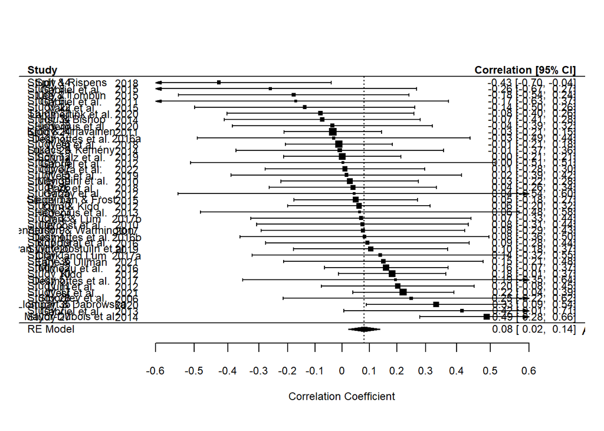

```r
# draw forest plot
forest(res, header=TRUE, atransf=transf.ztor, order="obs", xlim=c(-1.2, .9),
       at=transf.rtoz(seq(-0.6,0.6,by=0.1)), refline=coef(res), ilab=cbind(agg.Data.dat$Study, agg.Data.dat$Year),  ilab.xpos=c(-1,-.8), cex=.75)
text(c(-1.2, .9), c("Author(s)", "Year"))

### add text with Q-value, dfs, p-value, and I^2 statistic
text(-16, -1, pos=4, cex=0.75, bquote(paste("RE Model (Q = ",
     .(formatC(res$QE, digits=2, format="f")), ", df = ", .(res$k - res$p),
     ", p = ", .(formatC(res$QEp, digits=2, format="f")), "; ", I^2, " = ",
     .(formatC(res$I2, digits=1, format="f")), "%)")))
```

## Sensitivity analysis - Model with synthesised effect sizes for various correlation sizes

```r
#combine effect sizes with different correlation sizes

compute_rma <- function(cor, Study, Cor, N, Data) {
  d <- MAc::agg(id = Study, r = Cor, n = N, cor = cor, mod=NULL, data = Data)
  d <- escalc(measure = "ZCOR", ri = r, ni = n, data = d)
  rma(yi, vi, data= d, measure="OR", method="REML")
}

results = list()
for (cor in  seq(.1, 1,.2))  {
    results[[as.character(cor)]] = compute_rma(cor, Study, Cor, N, Data)
  }

print(results)
```

```
## $`0.1`
##
## Random-Effects Model (k = 39; tau^2 estimator: REML)
##
## tau^2 (estimated amount of total heterogeneity): 0.0219 (SE = 0.0114)
## tau (square root of estimated tau^2 value):      0.1481
## I^2 (total heterogeneity / total variability):   46.20%
## H^2 (total variability / sampling variability):  1.86
##
## Test for Heterogeneity:
## Q(df = 38) = 70.3991, p-val = 0.0011
##
## Model Results:
##
## estimate      se    zval    pval   ci.lb   ci.ub
##   0.1032  0.0369  2.7960  0.0052  0.0308  0.1755  **
##
## ---
## Signif. codes:  0 '***' 0.001 '**' 0.01 '*' 0.05 '.' 0.1 ' ' 1
##
##
## $`0.3`
##
## Random-Effects Model (k = 39; tau^2 estimator: REML)
##
## tau^2 (estimated amount of total heterogeneity): 0.0102 (SE = 0.0081)
## tau (square root of estimated tau^2 value):      0.1009
## I^2 (total heterogeneity / total variability):   28.50%
## H^2 (total variability / sampling variability):  1.40
##
## Test for Heterogeneity:
## Q(df = 38) = 50.0481, p-val = 0.0913
##
## Model Results:
##
## estimate      se    zval    pval   ci.lb   ci.ub
##   0.0882  0.0317  2.7869  0.0053  0.0262  0.1502  **
##
## ---
## Signif. codes:  0 '***' 0.001 '**' 0.01 '*' 0.05 '.' 0.1 ' ' 1
```

[output cut: 48 more lines]

```
## tau^2 (estimated amount of total heterogeneity): 0.0034 (SE = 0.0059)
## tau (square root of estimated tau^2 value):      0.0582
## I^2 (total heterogeneity / total variability):   11.69%
## H^2 (total variability / sampling variability):  1.13
##
## Test for Heterogeneity:
## Q(df = 38) = 35.4969, p-val = 0.5858
##
## Model Results:
##
## estimate      se    zval    pval   ci.lb   ci.ub
##   0.0720  0.0278  2.5894  0.0096  0.0175  0.1264  **
##
## ---
## Signif. codes:  0 '***' 0.001 '**' 0.01 '*' 0.05 '.' 0.1 ' ' 1
```

## Diagnostic

### Funnel Plots

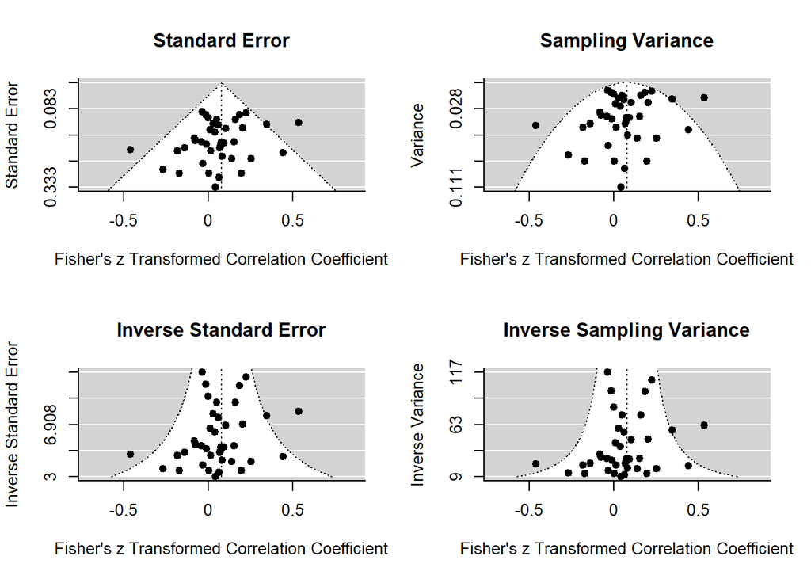

```r
### set up 2x2 array for plotting
par(mfrow=c(2,2))

### draw funnel plots
funnel(res, main="Standard Error")
funnel(res, yaxis="vi", main="Sampling Variance")
funnel(res, yaxis="seinv", main="Inverse Standard Error")
funnel(res, yaxis="vinv", main="Inverse Sampling Variance")
```

```r
dev.off()
```

```r
### funnel plot
funnel(res)

### create contour enhanced funnel plot (with funnel centered at 0)
funnel(res, level=c(90, 95, 99), shade=c("white", "orange", "red"), refline=0, legend = TRUE)
```

### Egger’s regression test/ PET-PEESE procedure

```r
#Tests for bias
regtest(res) # PET
```

```
##
## Regression Test for Funnel Plot Asymmetry
##
## Model:     mixed-effects meta-regression model
## Predictor: standard error
##
## Test for Funnel Plot Asymmetry: z = -1.4146, p = 0.1572
## Limit Estimate (as sei -> 0):   b = 0.1978 (CI: 0.0257, 0.3699)
```

```r
regtest(res, predictor="vi") # PEESE
```

```
##
## Regression Test for Funnel Plot Asymmetry
##
## Model:     mixed-effects meta-regression model
## Predictor: sampling variance
##
## Test for Funnel Plot Asymmetry: z = -1.3938, p = 0.1634
## Limit Estimate (as vi -> 0):    b = 0.1359 (CI: 0.0396, 0.2323)
```

### Rank correlation test

```r
#Tests for bias
ranktest(res, exact = FALSE)
```

```
##
## Rank Correlation Test for Funnel Plot Asymmetry
##
## Kendall's tau = -0.0706, p = 0.5290
```

Both ranktest and Egger’s regression test do not test directly for publication bias. Instead, they indicate whether there’s evidence that the funnel plot is asymmetric, which may occur due to publication bias, but not exclusively. According to these results there’s no evidence that there is plot asymmetry.

### Outlier/influential points detection

```r
par("mar")
```

```
## [1] 5.1 4.1 4.1 2.1
```

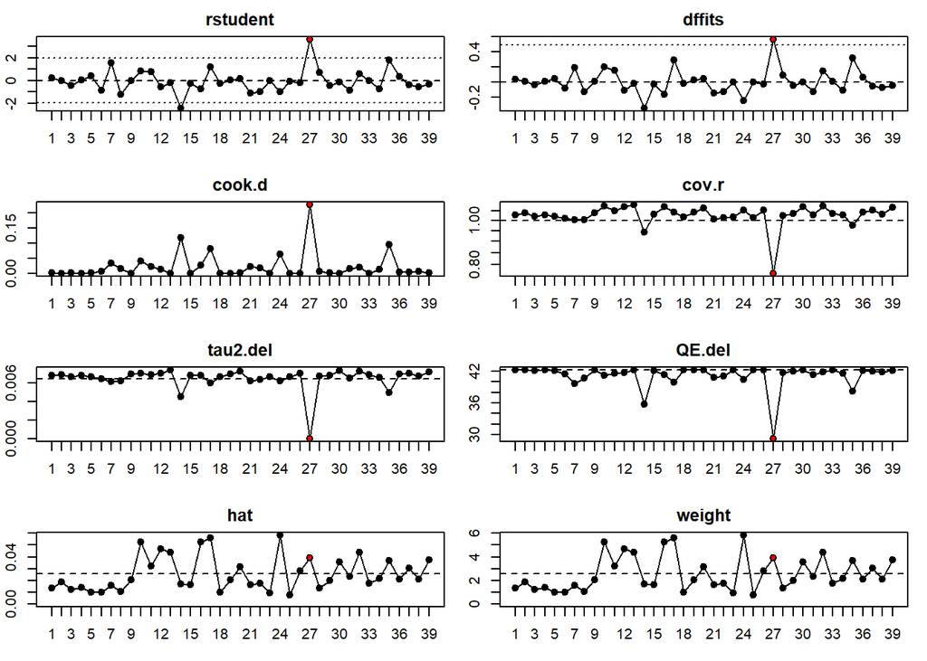

```r
### calculate influence diagnostics
inf <- influence(res)

### plot the influence diagnostics
plot(inf)
```

# Overall model with dependency

```r
# Overall model with dependencies: general model

intercept.model <- robu(formula = yi ~ 1, data = Data,
                       studynum = Study, var.eff.size = vi,
                       rho = .8, small = TRUE)
print(intercept.model)
```

```
## RVE: Correlated Effects Model with Small-Sample Corrections
##
## Model: yi ~ 1
##
## Number of studies = 39
## Number of outcomes = 478 (min = 1 , mean = 12.3 , median = 6 , max = 70 )
## Rho = 0.8
## I.sq = 46.23562
## Tau.sq = 0.02244067
##
##                Estimate StdErr t-value  dfs P(|t|>) 95% CI.L 95% CI.U Sig
## 1 X.Intercept.   0.0619 0.0269     2.3 32.7  0.0281  0.00709    0.117  **
## ---
## Signif. codes: < .01 *** < .05 ** < .10 *
## ---
## Note: If df < 4, do not trust the results
```

```r
sensitivity(intercept.model)
```

```
## RVE: Correlated Effects Model with Small-Sample Corrections
## Model: yi ~ 1
##
## Sensitivity Analysis
##
##                           Rho = 0 Rho = 0.2 Rho = 0.4 Rho = 0.6 Rho = 0.8
##  X.Intercept. Coefficient 0.0620  0.0620    0.0619    0.0619    0.0619
##               Std. Error  0.0269  0.0269    0.0269    0.0269    0.0269
##  Tau.sq       Estimate    0.0221  0.0222    0.0223    0.0224    0.0224
##  Rho = 1
##  0.0619
##  0.0269
##  0.0225
```

## Forest plot

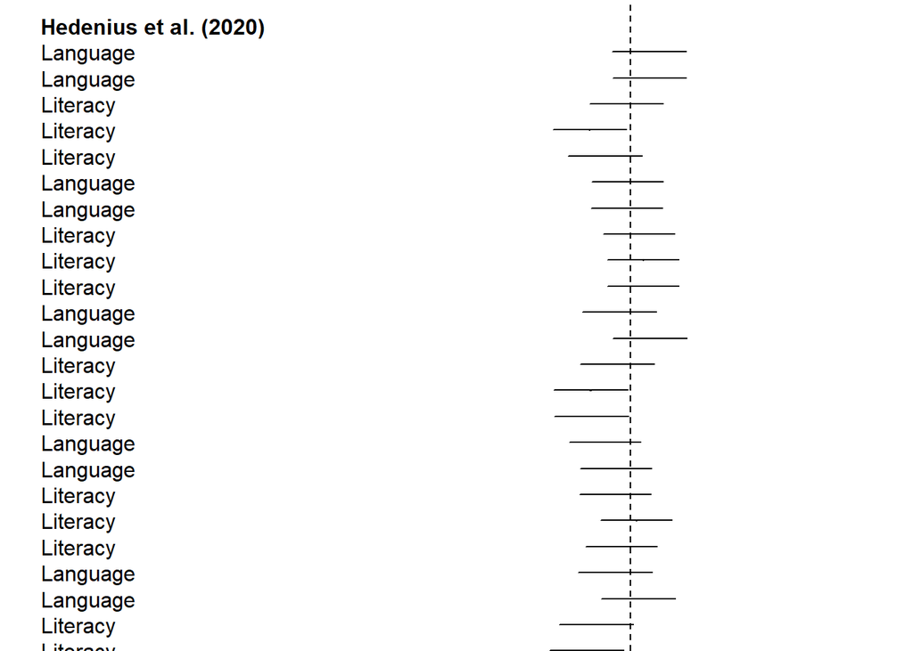

```r
forest.robu(intercept.model, es.lab = "Variable", study.lab = "Study")
```

## Diagnostic

### Egger’s regression test/ PET-PEESE procedure

```r
# with un-corrected ES (PET) - use standard error as predictor
PET <- robu(formula = yi ~ sei, data = Data,
                       studynum = Study, var.eff.size = vi,
                       rho = .8, small = TRUE)
print(PET)
```

```
## RVE: Correlated Effects Model with Small-Sample Corrections
##
## Model: yi ~ sei
##
## Number of studies = 39
## Number of outcomes = 478 (min = 1 , mean = 12.3 , median = 6 , max = 70 )
## Rho = 0.8
## I.sq = 45.84318
## Tau.sq = 0.02223951
##
##                Estimate StdErr t-value  dfs P(|t|>) 95% CI.L 95% CI.U Sig
## 1 X.Intercept.    0.176 0.0743    2.37 17.5  0.0295   0.0197    0.332  **
## 2          sei   -0.680 0.3767   -1.80 21.4  0.0854  -1.4620    0.103   *
## ---
## Signif. codes: < .01 *** < .05 ** < .10 *
## ---
## Note: If df < 4, do not trust the results
```

```r
# with un-corrected ES (PEESE) - use variance as predictor
PEESE <- robu(formula = yi ~ vi, data = Data,
                       studynum = Study, var.eff.size = vi,
                       rho = .8, small = TRUE)
print(PEESE)
```

```
## RVE: Correlated Effects Model with Small-Sample Corrections
##
## Model: yi ~ vi
##
## Number of studies = 39
## Number of outcomes = 478 (min = 1 , mean = 12.3 , median = 6 , max = 70 )
## Rho = 0.8
## I.sq = 45.95285
## Tau.sq = 0.02222574
##
##                Estimate StdErr t-value  dfs P(|t|>) 95% CI.L 95% CI.U Sig
## 1 X.Intercept.    0.111 0.0441    2.52 18.0  0.0213   0.0185    0.204  **
## 2           vi   -1.536 0.9279   -1.66 16.1  0.1171  -3.5018    0.430
## ---
## Signif. codes: < .01 *** < .05 ** < .10 *
## ---
## Note: If df < 4, do not trust the results
```

## Moderators

### Overall Model with Variable - Language vs Literacy

```r
#without intercept
Var.model<- robu(formula = yi ~ factor(Variable)-1, data = Data, studynum = Study, var.eff.size = vi,  rho = .8, small = TRUE)
print(Var.model)
```

```
## RVE: Correlated Effects Model with Small-Sample Corrections
##
## Model: yi ~ factor(Variable) - 1
##
## Number of studies = 39
## Number of outcomes = 478 (min = 1 , mean = 12.3 , median = 6 , max = 70 )
## Rho = 0.8
## I.sq = 46.71539
## Tau.sq = 0.02312185
##
##                            Estimate StdErr t-value  dfs P(|t|>)  95% CI.L
## 1 factor.Variable.Language   0.0689 0.0368    1.87 25.5  0.0725 -0.006763
## 2 factor.Variable.Literacy   0.0451 0.0205    2.20 13.3  0.0464  0.000829
##   95% CI.U Sig
## 1   0.1446   *
## 2   0.0894  **
## ---
## Signif. codes: < .01 *** < .05 ** < .10 *
## ---
## Note: If df < 4, do not trust the results
```

```r
sensitivity(Var.model)
```

```
## RVE: Correlated Effects Model with Small-Sample Corrections
## Model: yi ~ factor(Variable) - 1
##
## Sensitivity Analysis
##
##                                       Rho = 0 Rho = 0.2 Rho = 0.4 Rho = 0.6
##  factor.Variable.Language Coefficient 0.0692  0.0691    0.0690    0.0690
##                           Std. Error  0.0368  0.0368    0.0368    0.0368
##  factor.Variable.Literacy Coefficient 0.0451  0.0451    0.0451    0.0451
##                           Std. Error  0.0206  0.0206    0.0206    0.0206
##  Tau.sq                   Estimate    0.0226  0.0227    0.0229    0.0230
##  Rho = 0.8 Rho = 1
##  0.0689    0.0689
##  0.0368    0.0368
##  0.0451    0.0451
##  0.0205    0.0205
##  0.0231    0.0232
```

```r
#run pairwise comparisons between variables
Wald_test(Var.model, constraints = constrain_pairwise(1:2), vcov = "CR2", tidy = TRUE)
```

```
##                                           hypothesis test Fstat df_num df_denom
##  factor.Variable.Literacy - factor.Variable.Language  HTZ 0.344      1     22.3
##  p_val sig
##  0.563
```

### Overall Model with Group

```r
stats::addmargins(table(Data$Variable, Data$Group))
```

```
##
##             DD DLD  TD Sum
##   Language  30 120 173 323
##   Literacy  47  22  86 155
##   Sum       77 142 259 478
```

```r
#Set Group as factor
Data$Group <- as.factor(Data$Group)

#without intercept
Group.model<- robu(formula = yi ~ 0 + Group, data = Data, studynum = Study, var.eff.size = vi,  rho = .8, small = TRUE)
print(Group.model)
```

```
## RVE: Correlated Effects Model with Small-Sample Corrections
##
## Model: yi ~ 0 + Group
##
## Number of studies = 39
## Number of outcomes = 478 (min = 1 , mean = 12.3 , median = 6 , max = 70 )
## Rho = 0.8
## I.sq = 46.63461
## Tau.sq = 0.0229956
##
##            Estimate StdErr t-value   dfs P(|t|>) 95% CI.L 95% CI.U Sig
## 1  GroupDD   0.0608 0.0544    1.12  7.57   0.298  -0.0659    0.188
## 2 GroupDLD   0.1024 0.0880    1.16 12.44   0.266  -0.0885    0.293
## 3  GroupTD   0.0487 0.0285    1.71 22.49   0.101  -0.0103    0.108
## ---
## Signif. codes: < .01 *** < .05 ** < .10 *
## ---
## Note: If df < 4, do not trust the results
```

```r
sensitivity(Group.model)
```

```
## RVE: Correlated Effects Model with Small-Sample Corrections
## Model: yi ~ 0 + Group
##
## Sensitivity Analysis
##
##                       Rho = 0 Rho = 0.2 Rho = 0.4 Rho = 0.6 Rho = 0.8 Rho = 1
##  GroupDD  Coefficient 0.0610  0.0609    0.0609    0.0609    0.0608    0.0608
##           Std. Error  0.0544  0.0544    0.0544    0.0544    0.0544    0.0544
##  GroupDLD Coefficient 0.1029  0.1028    0.1027    0.1025    0.1024    0.1023
##           Std. Error  0.0884  0.0883    0.0882    0.0881    0.0880    0.0879
##  GroupTD  Coefficient 0.0489  0.0488    0.0488    0.0487    0.0487    0.0487
##           Std. Error  0.0284  0.0284    0.0285    0.0285    0.0285    0.0285
##  Tau.sq   Estimate    0.0223  0.0225    0.0227    0.0228    0.0230    0.0232
```

```r
#test overall group effect
Wald_test(Group.model, constraints = matrix(c(1,0,0,0,1,0,0,0,1),3,3), vcov = "CR2")
```

```
##  test Fstat df_num df_denom p_val sig
##   HTZ  1.81      3     19.2  0.18
```

```r
#run pairwise comparisons between groups
Wald_test(Group.model, constraints = constrain_pairwise(1:3), vcov = "CR2", tidy = TRUE)
```

```
##          hypothesis test  Fstat df_num df_denom p_val sig
##  GroupDLD - GroupDD  HTZ 0.1616      1     15.5 0.693
##   GroupTD - GroupDD  HTZ 0.0358      1     10.1 0.854
##  GroupTD - GroupDLD  HTZ 0.3391      1     19.0 0.567
```

### Overall Model with Age

```r
#without intercept

Age.model<- robu(formula = yi ~ Age, data = Data, studynum = Study, var.eff.size = vi,  rho = .8, small = TRUE)
print(Age.model)
```

```
## RVE: Correlated Effects Model with Small-Sample Corrections
##
## Model: yi ~ Age
##
## Number of studies = 39
## Number of outcomes = 478 (min = 1 , mean = 12.3 , median = 6 , max = 70 )
## Rho = 0.8
## I.sq = 47.28305
## Tau.sq = 0.0240015
##
##                Estimate StdErr t-value   dfs P(|t|>) 95% CI.L 95% CI.U Sig
## 1 X.Intercept.   0.0618 0.0274   2.254 31.57  0.0313  0.00593   0.1178  **
## 2          Age   0.0134 0.0196   0.681  9.69  0.5118 -0.03054   0.0573
## ---
## Signif. codes: < .01 *** < .05 ** < .10 *
## ---
## Note: If df < 4, do not trust the results
```

```r
sensitivity(Age.model)
```

```
## RVE: Correlated Effects Model with Small-Sample Corrections
## Model: yi ~ Age
##
## Sensitivity Analysis
##
##                           Rho = 0 Rho = 0.2 Rho = 0.4 Rho = 0.6 Rho = 0.8
##  X.Intercept. Coefficient 0.0620  0.0620    0.0619    0.0619    0.0618
##               Std. Error  0.0275  0.0275    0.0274    0.0274    0.0274
##  Age          Coefficient 0.0133  0.0133    0.0133    0.0134    0.0134
##               Std. Error  0.0196  0.0196    0.0196    0.0196    0.0196
##  Tau.sq       Estimate    0.0234  0.0236    0.0237    0.0239    0.0240
##  Rho = 1
##  0.0618
##  0.0274
##  0.0134
##  0.0196
##  0.0242
```

# Modelling - Language

## Model with synthesised effect sizes

```r
agg.Data.lang <- MAc::agg(id = Study, r = Cor, n = N, cor = .5, mod=NULL, data = Data_language)
agg.Data.lang  <- escalc(measure = "ZCOR", ri = r, ni = n, data = agg.Data.lang)

#add details
agg.Data.lang <- as.data.frame(list(agg.Data.lang, study.details) %>% reduce(left_join, by = c("id")))

### fit fixed-effects model
res_lang <- rma(yi, vi, data= agg.Data.lang)
print(res_lang)
```

```
##
## Random-Effects Model (k = 35; tau^2 estimator: REML)
##
## tau^2 (estimated amount of total heterogeneity): 0.0097 (SE = 0.0084)
## tau (square root of estimated tau^2 value):      0.0986
## I^2 (total heterogeneity / total variability):   27.77%
## H^2 (total variability / sampling variability):  1.38
##
## Test for Heterogeneity:
## Q(df = 34) = 44.1037, p-val = 0.1150
##
## Model Results:
##
## estimate      se    zval    pval   ci.lb   ci.ub
##   0.0789  0.0330  2.3896  0.0169  0.0142  0.1436  *
##
## ---
## Signif. codes:  0 '***' 0.001 '**' 0.01 '*' 0.05 '.' 0.1 ' ' 1
```

```r
predict(res_lang, digits=3, transf=transf.ztor)
```

```
##
##   pred ci.lb ci.ub  pi.lb pi.ub
##  0.079 0.014 0.143 -0.124 0.275
```

## Sensitivity analysis - Model with synthesised effect sizes

```r
#combine effect sizes with different correlation sizes

compute_rma <- function(cor, Study, Cor, N, Data) {
  d <- MAc::agg(id = Study, r = Cor, n = N, cor = cor, mod=NULL, data = Data_language)
  d <- escalc(measure = "ZCOR", ri = r, ni = n, data = d)
  rma(yi, vi, data= d, measure="OR", method="REML")
}

results = list()
for (cor in  seq(.1, 1,.2))  {
    results[[as.character(cor)]] = compute_rma(cor, Study, Cor, N, Data)
  }

print(results)
```

```
## $`0.1`
##
## Random-Effects Model (k = 35; tau^2 estimator: REML)
##
## tau^2 (estimated amount of total heterogeneity): 0.0271 (SE = 0.0135)
## tau (square root of estimated tau^2 value):      0.1647
## I^2 (total heterogeneity / total variability):   51.73%
## H^2 (total variability / sampling variability):  2.07
##
## Test for Heterogeneity:
## Q(df = 34) = 68.9940, p-val = 0.0004
##
## Model Results:
##
## estimate      se    zval    pval   ci.lb   ci.ub
##   0.0932  0.0409  2.2783  0.0227  0.0130  0.1733  *
##
## ---
## Signif. codes:  0 '***' 0.001 '**' 0.01 '*' 0.05 '.' 0.1 ' ' 1
##
##
## $`0.3`
##
## Random-Effects Model (k = 35; tau^2 estimator: REML)
##
## tau^2 (estimated amount of total heterogeneity): 0.0139 (SE = 0.0097)
## tau (square root of estimated tau^2 value):      0.1180
## I^2 (total heterogeneity / total variability):   35.50%
## H^2 (total variability / sampling variability):  1.55
##
## Test for Heterogeneity:
## Q(df = 34) = 51.1660, p-val = 0.0296
##
## Model Results:
##
## estimate      se    zval    pval   ci.lb   ci.ub
##   0.0837  0.0352  2.3797  0.0173  0.0148  0.1526  *
##
## ---
## Signif. codes:  0 '***' 0.001 '**' 0.01 '*' 0.05 '.' 0.1 ' ' 1
```

[output cut: 48 more lines]

```
## tau^2 (estimated amount of total heterogeneity): 0.0062 (SE = 0.0072)
## tau (square root of estimated tau^2 value):      0.0785
## I^2 (total heterogeneity / total variability):   19.59%
## H^2 (total variability / sampling variability):  1.24
##
## Test for Heterogeneity:
## Q(df = 34) = 37.4002, p-val = 0.3157
##
## Model Results:
##
## estimate      se    zval    pval   ci.lb   ci.ub
##   0.0728  0.0310  2.3491  0.0188  0.0121  0.1335  *
##
## ---
## Signif. codes:  0 '***' 0.001 '**' 0.01 '*' 0.05 '.' 0.1 ' ' 1
```

## Forest plot

```r
# back-transform the results to correlations and obtain the prediction interval
predict(res_lang, transf=transf.ztor, digits=2)
```

```
##
##  pred ci.lb ci.ub pi.lb pi.ub
##  0.08  0.01  0.14 -0.12  0.28
```

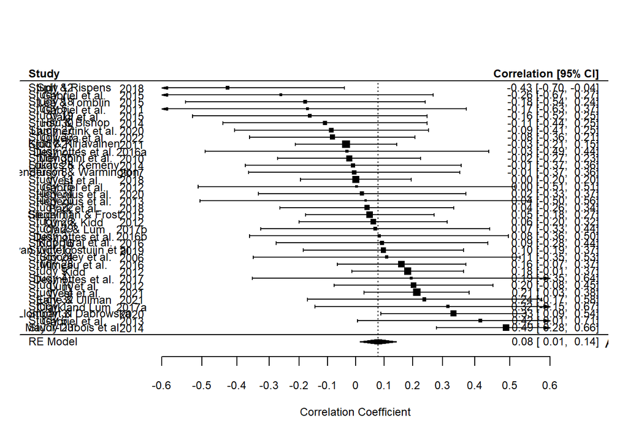

```r
# draw forest plot
forest(res_lang, header=TRUE, atransf=transf.ztor, order="obs", xlim=c(-1.2, .9),
       at=transf.rtoz(seq(-0.6,0.6,by=0.1)), refline=coef(res_lang), ilab=cbind(agg.Data.lang$Study, agg.Data.lang$Year),  ilab.xpos=c(-1,-.8), cex=.75)
text(c(-1.2, .9), c("Author(s)", "Year"))
```

```r
dev.copy(jpeg,filename="forest.lang.jpg");
```

```r
dev.off ();
```

## Diagnostics

### Funnel plots

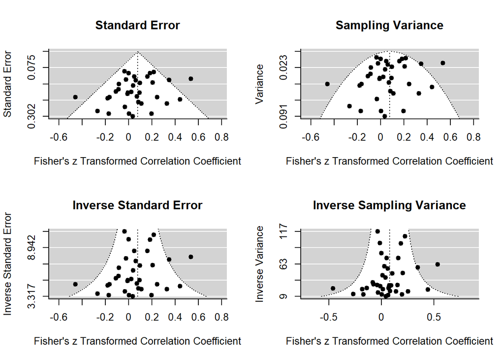

```r
### set up 2x2 array for plotting
par(mfrow=c(2,2))

### draw funnel plots
funnel(res_lang, main="Standard Error")
funnel(res_lang, yaxis="vi", main="Sampling Variance")
funnel(res_lang, yaxis="seinv", main="Inverse Standard Error")
funnel(res, yaxis="vinv", main="Inverse Sampling Variance")
```

```r
dev.off()
```

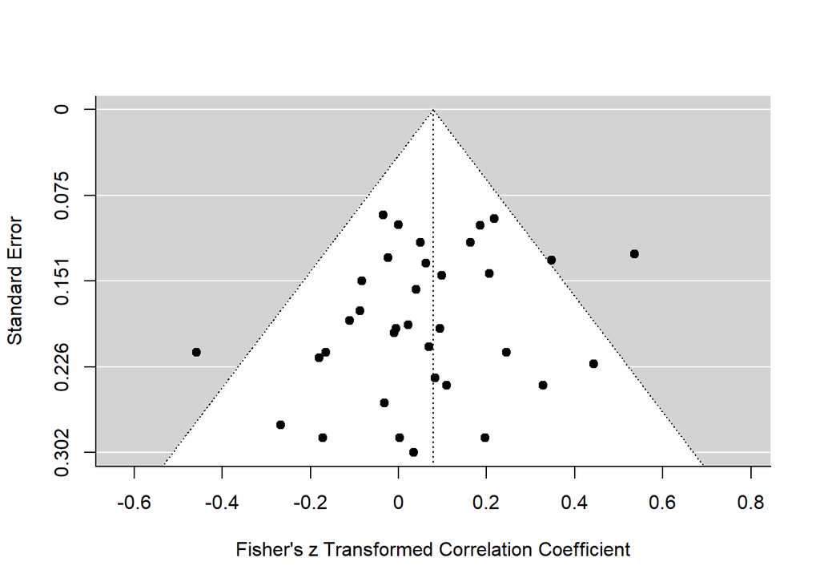

```r
### funnel plot
funnel(res_lang)
```

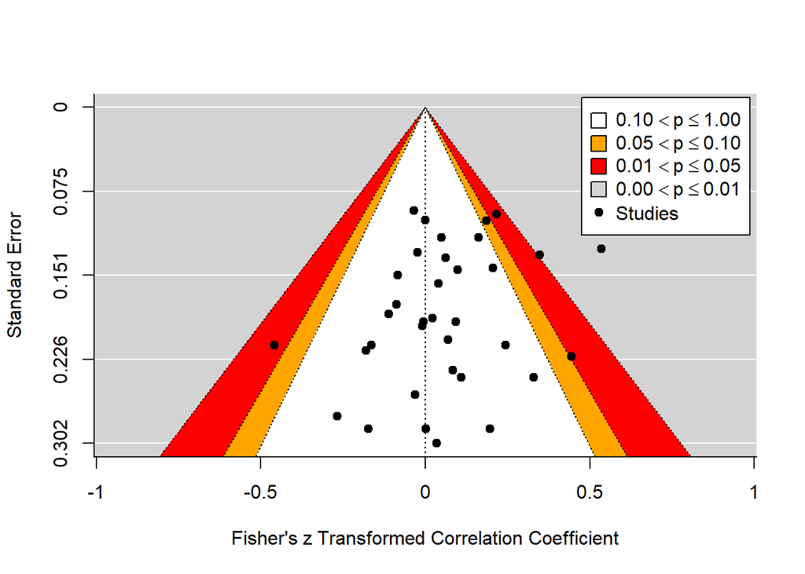

```r
### create contour enhanced funnel plot (with funnel centered at 0)
funnel(res_lang, level=c(90, 95, 99), shade=c("white", "orange", "red"), refline=0, legend=TRUE)
```

### PET-PEESE

```r
#Tests for bias
regtest(res_lang) # PET
```

```
##
## Regression Test for Funnel Plot Asymmetry
##
## Model:     mixed-effects meta-regression model
## Predictor: standard error
##
## Test for Funnel Plot Asymmetry: z = -1.4294, p = 0.1529
## Limit Estimate (as sei -> 0):   b = 0.2123 (CI: 0.0190, 0.4057)
```

```r
regtest(res_lang, predictor="vi") # PEESE
```

```
##
## Regression Test for Funnel Plot Asymmetry
##
## Model:     mixed-effects meta-regression model
## Predictor: sampling variance
##
## Test for Funnel Plot Asymmetry: z = -1.3988, p = 0.1619
## Limit Estimate (as vi -> 0):    b = 0.1429 (CI: 0.0335, 0.2523)
```

### Outlier/influential points detection

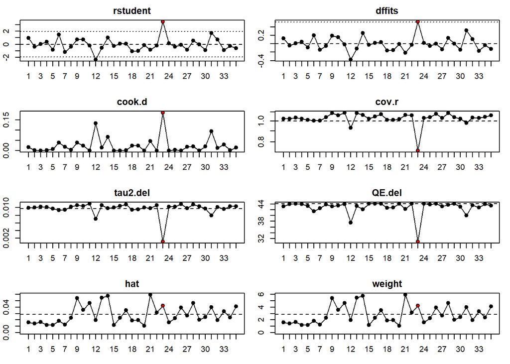

```r
### calculate influence diagnostics
inf_lang <- influence(res_lang)

### plot the influence diagnostics
plot(inf_lang)
```

## Language Model with dependencies

```r
# Overall model with dependencies: general model

intercept.lang.model <- robu(formula = yi ~ 1, data = Data_language,
                       studynum = Study, var.eff.size = vi,
                       rho = .8, small = TRUE)
print(intercept.lang.model)
```

```
## RVE: Correlated Effects Model with Small-Sample Corrections
##
## Model: yi ~ 1
##
## Number of studies = 35
## Number of outcomes = 323 (min = 1 , mean = 9.23 , median = 4 , max = 48 )
## Rho = 0.8
## I.sq = 51.7241
## Tau.sq = 0.02764338
##
##                Estimate StdErr t-value  dfs P(|t|>) 95% CI.L 95% CI.U Sig
## 1 X.Intercept.   0.0606 0.0306    1.98 30.1   0.057 -0.00191    0.123   *
## ---
## Signif. codes: < .01 *** < .05 ** < .10 *
## ---
## Note: If df < 4, do not trust the results
```

```r
sensitivity(intercept.lang.model)
```

```
## RVE: Correlated Effects Model with Small-Sample Corrections
## Model: yi ~ 1
##
## Sensitivity Analysis
##
##                           Rho = 0 Rho = 0.2 Rho = 0.4 Rho = 0.6 Rho = 0.8
##  X.Intercept. Coefficient 0.0606  0.0606    0.0606    0.0606    0.0606
##               Std. Error  0.0306  0.0306    0.0306    0.0306    0.0306
##  Tau.sq       Estimate    0.0273  0.0274    0.0275    0.0276    0.0276
##  Rho = 1
##  0.0605
##  0.0306
##  0.0277
```

### Forest plot

```r
pdf(file = "forestplot_lang.pdf", width = 20, height = 42, pointsize = 5)

forest.robu(intercept.lang.model, es.lab = "Component", study.lab = "Study", "Effect Size" = yi)

dev.off()
```

### Diagnostic

#### Egger’s regression test/ PET-PEESE procedure

```r
# with un-corrected ES (PET) - use standard error as predictor
PET_lang <- robu(formula = yi ~ sei, data = Data_language,
                       studynum = Study, var.eff.size = vi,
                       rho = .8, small = TRUE)
print(PET_lang)
```

```
## RVE: Correlated Effects Model with Small-Sample Corrections
##
## Model: yi ~ sei
##
## Number of studies = 35
## Number of outcomes = 323 (min = 1 , mean = 9.23 , median = 4 , max = 48 )
## Rho = 0.8
## I.sq = 51.22284
## Tau.sq = 0.02729829
##
##                Estimate StdErr t-value  dfs P(|t|>) 95% CI.L 95% CI.U Sig
## 1 X.Intercept.    0.185 0.0849    2.18 15.9  0.0444  0.00524    0.366  **
## 2          sei   -0.739 0.4499   -1.64 19.0  0.1169 -1.68063    0.203
## ---
## Signif. codes: < .01 *** < .05 ** < .10 *
## ---
## Note: If df < 4, do not trust the results
```

```r
# with un-corrected ES (PEESE) - use variance as predictor
PEESE_lang <- robu(formula = yi ~ vi, data = Data_language,
                       studynum = Study, var.eff.size = vi,
                       rho = .8, small = TRUE)
print(PEESE_lang)
```

```
## RVE: Correlated Effects Model with Small-Sample Corrections
##
## Model: yi ~ vi
##
## Number of studies = 35
## Number of outcomes = 323 (min = 1 , mean = 9.23 , median = 4 , max = 48 )
## Rho = 0.8
## I.sq = 51.47587
## Tau.sq = 0.02742361
##
##                Estimate StdErr t-value  dfs P(|t|>) 95% CI.L 95% CI.U Sig
## 1 X.Intercept.    0.111 0.0509    2.18 16.3  0.0444  0.00314    0.219  **
## 2           vi   -1.560 1.1858   -1.32 13.9  0.2097 -4.10419    0.985
## ---
## Signif. codes: < .01 *** < .05 ** < .10 *
## ---
## Note: If df < 4, do not trust the results
```

### Moderators

#### Language model - age as predictor

```r
# Overall model with dependencies: general model

lang.age <- robu(formula = yi ~ Age, data = Data_language,
                       studynum = Study, var.eff.size = vi,
                       rho = .8, small = TRUE)
print(lang.age)
```

```
## RVE: Correlated Effects Model with Small-Sample Corrections
##
## Model: yi ~ Age
##
## Number of studies = 35
## Number of outcomes = 323 (min = 1 , mean = 9.23 , median = 4 , max = 48 )
## Rho = 0.8
## I.sq = 52.61026
## Tau.sq = 0.0292834
##
##                Estimate  StdErr t-value  dfs P(|t|>) 95% CI.L 95% CI.U Sig
## 1 X.Intercept.  0.02260 0.05939   0.380 16.6   0.708 -0.10295   0.1481
## 2          Age  0.00316 0.00551   0.575 10.0   0.578 -0.00911   0.0154
## ---
## Signif. codes: < .01 *** < .05 ** < .10 *
## ---
## Note: If df < 4, do not trust the results
```

```r
sensitivity(lang.age)
```

```
## RVE: Correlated Effects Model with Small-Sample Corrections
## Model: yi ~ Age
##
## Sensitivity Analysis
##
##                           Rho = 0 Rho = 0.2 Rho = 0.4 Rho = 0.6 Rho = 0.8
##  X.Intercept. Coefficient 0.02271 0.02268   0.02265   0.02262   0.02260
##               Std. Error  0.05939 0.05939   0.05939   0.05939   0.05939
##  Age          Coefficient 0.00317 0.00317   0.00317   0.00317   0.00316
##               Std. Error  0.00551 0.00551   0.00551   0.00551   0.00551
##  Tau.sq       Estimate    0.02874 0.02887   0.02901   0.02915   0.02928
##  Rho = 1
##  0.02257
##  0.05939
##  0.00316
##  0.00551
##  0.02942
```

#### Language model - group as predictor

```r
# Overall model with dependencies: general model

Data_language$Group <- as.factor(Data_language$Group)
Data_language$Group <- relevel(Data_language$Group, ref= "TD")

lang.group <- robu(formula = yi ~ as.factor(Group)-1, data = Data_language,
                       studynum = Study, var.eff.size = vi,
                       rho = .8, small = TRUE)
print(lang.group)
```

```
## RVE: Correlated Effects Model with Small-Sample Corrections
##
## Model: yi ~ as.factor(Group) - 1
##
## Number of studies = 35
## Number of outcomes = 323 (min = 1 , mean = 9.23 , median = 4 , max = 48 )
## Rho = 0.8
## I.sq = 52.57219
## Tau.sq = 0.02887407
##
##                       Estimate StdErr t-value  dfs P(|t|>) 95% CI.L 95% CI.U
## 1  as.factor.Group.TD   0.0564 0.0328   1.719 21.3   0.100  -0.0118    0.125
## 2  as.factor.Group.DD   0.0298 0.0597   0.500  5.5   0.637  -0.1196    0.179
## 3 as.factor.Group.DLD   0.0826 0.0901   0.917 12.8   0.376  -0.1124    0.278
##   Sig
## 1
## 2
## 3
## ---
## Signif. codes: < .01 *** < .05 ** < .10 *
## ---
## Note: If df < 4, do not trust the results
```

```r
sensitivity(lang.group)
```

```
## RVE: Correlated Effects Model with Small-Sample Corrections
## Model: yi ~ as.factor(Group) - 1
##
## Sensitivity Analysis
##
##                                  Rho = 0 Rho = 0.2 Rho = 0.4 Rho = 0.6
##  as.factor.Group.TD  Coefficient 0.0565  0.0565    0.0565    0.0564
##                      Std. Error  0.0328  0.0328    0.0328    0.0328
##  as.factor.Group.DD  Coefficient 0.0299  0.0299    0.0299    0.0299
##                      Std. Error  0.0596  0.0597    0.0597    0.0597
##  as.factor.Group.DLD Coefficient 0.0830  0.0829    0.0828    0.0827
##                      Std. Error  0.0904  0.0903    0.0902    0.0902
##  Tau.sq              Estimate    0.0283  0.0285    0.0286    0.0287
##  Rho = 0.8 Rho = 1
##  0.0564    0.0564
##  0.0328    0.0328
##  0.0298    0.0298
##  0.0597    0.0598
##  0.0826    0.0826
##  0.0901    0.0900
##  0.0289    0.0290
```

```r
#test overall group effect (i.e. do estimates differ from zero)
Wald_test(lang.group, constraints = matrix(c(1,0,0,0,1,0,0,0,1),3,3), vcov = "CR2", tidy = TRUE)
```

```
##  test Fstat df_num df_denom p_val sig
##   HTZ  1.23      3     15.6 0.333
```

```r
#run comparisons between groups (i.e. do estimates differ from each other)
V_lang.group <- vcovCR(lang.group, type = "CR2")
Wald_test(lang.group, constraints = constrain_equal(1:3), vcov = V_lang.group)
```

```
##  test Fstat df_num df_denom p_val sig
##   HTZ 0.124      2     13.2 0.884
```

#### Language model - component as predictor

```r
# Overall model with dependencies: general model
df <- subset(Data_language, (Component %in% c("Grammar","Vocabulary","Phonology")))

lang.component <- robu(formula = yi ~ 0 + Component, data = df,
                       studynum = Study, var.eff.size = vi,
                       rho = .8, small = TRUE)
print(lang.component)
```

```
## RVE: Correlated Effects Model with Small-Sample Corrections
##
## Model: yi ~ 0 + Component
##
## Number of studies = 35
## Number of outcomes = 313 (min = 1 , mean = 8.94 , median = 4 , max = 48 )
## Rho = 0.8
## I.sq = 53.12239
## Tau.sq = 0.03041199
##
##                       Estimate StdErr t-value   dfs P(|t|>) 95% CI.L 95% CI.U
## 1    ComponentGrammar   0.0406 0.0385    1.05 16.71   0.307  -0.0407    0.122
## 2  ComponentPhonology   0.0883 0.0790    1.12  9.51   0.291  -0.0889    0.266
## 3 ComponentVocabulary   0.0670 0.0436    1.54  8.63   0.160  -0.0322    0.166
##   Sig
## 1
## 2
## 3
## ---
## Signif. codes: < .01 *** < .05 ** < .10 *
## ---
## Note: If df < 4, do not trust the results
```

```r
sensitivity(lang.component)
```

```
## RVE: Correlated Effects Model with Small-Sample Corrections
## Model: yi ~ 0 + Component
##
## Sensitivity Analysis
##
##                                  Rho = 0 Rho = 0.2 Rho = 0.4 Rho = 0.6
##  ComponentGrammar    Coefficient 0.0407  0.0407    0.0406    0.0406
##                      Std. Error  0.0384  0.0384    0.0384    0.0384
##  ComponentPhonology  Coefficient 0.0886  0.0885    0.0884    0.0884
##                      Std. Error  0.0792  0.0791    0.0791    0.0790
##  ComponentVocabulary Coefficient 0.0672  0.0671    0.0671    0.0670
##                      Std. Error  0.0436  0.0436    0.0436    0.0436
##  Tau.sq              Estimate    0.0298  0.0299    0.0301    0.0303
##  Rho = 0.8 Rho = 1
##  0.0406    0.0405
##  0.0385    0.0385
##  0.0883    0.0883
##  0.0790    0.0789
##  0.0670    0.0669
##  0.0436    0.0435
##  0.0304    0.0306
```

```r
#test overall component effect (i.e. do estimates differ from zero)
Wald_test(lang.component, constraints = matrix(c(1,0,0,0,1,0,0,0,1),3,3), vcov = "CR2",tidy = TRUE)
```

```
##  test Fstat df_num df_denom p_val sig
##   HTZ  1.26      3     17.6 0.318
```

```r
#run comparisons between components (i.e. do estimates differ from each other)
V_lang.component <- vcovCR(lang.component, type = "CR2")
Wald_test(lang.component, constraints = constrain_equal(1:3), vcov = V_lang.component)
```

```
##  test Fstat df_num df_denom p_val sig
##   HTZ 0.213      2     18.8  0.81
```

#### Language model - Sequence complexity

```r
# Overall model with dependencies: general model )

lang.seq.complexity <- robu(formula = yi ~ as.factor(Seq_complexity)-1, data = Data_language[Data_language$Seq_complexity == "FOC" | Data_language$Seq_complexity == "SOC", ],
                       studynum = Study, var.eff.size = vi,
                       rho = .8, small = TRUE)
print(lang.seq.complexity)
```

```
## RVE: Correlated Effects Model with Small-Sample Corrections
##
## Model: yi ~ as.factor(Seq_complexity) - 1
##
## Number of studies = 33
## Number of outcomes = 298 (min = 1 , mean = 9.03 , median = 4 , max = 48 )
## Rho = 0.8
## I.sq = 50.63132
## Tau.sq = 0.02614845
##
##                                Estimate StdErr t-value  dfs P(|t|>) 95% CI.L
## 1 as.factor.Seq_complexity.FOC   0.0813 0.0450    1.81 14.6  0.0914  -0.0148
## 2 as.factor.Seq_complexity.SOC   0.0604 0.0367    1.65 13.0  0.1236  -0.0188
##   95% CI.U Sig
## 1    0.177   *
## 2    0.140
## ---
## Signif. codes: < .01 *** < .05 ** < .10 *
## ---
## Note: If df < 4, do not trust the results
```

```r
sensitivity(lang.seq.complexity)
```

```
## RVE: Correlated Effects Model with Small-Sample Corrections
## Model: yi ~ as.factor(Seq_complexity) - 1
##
## Sensitivity Analysis
##
##                                           Rho = 0 Rho = 0.2 Rho = 0.4 Rho = 0.6
##  as.factor.Seq_complexity.FOC Coefficient 0.0815  0.0814    0.0814    0.0813
##                               Std. Error  0.0451  0.0450    0.0450    0.0450
##  as.factor.Seq_complexity.SOC Coefficient 0.0606  0.0605    0.0605    0.0604
##                               Std. Error  0.0367  0.0367    0.0367    0.0367
##  Tau.sq                       Estimate    0.0255  0.0257    0.0258    0.0260
##  Rho = 0.8 Rho = 1
##  0.0813    0.0813
##  0.0450    0.0450
##  0.0604    0.0603
##  0.0367    0.0367
##  0.0261    0.0263
```

```r
#run comparisons between groups
V_seq.complexity <- vcovCR(lang.seq.complexity, type = "CR2")

#test overall seq.complexity effect (i.e. do estimates differ from zero)
Wald_test(lang.seq.complexity, constraints = constrain_zero(1:2), vcov = V_seq.complexity)
```

```
##  test Fstat df_num df_denom  p_val sig
##   HTZ  2.85      2     19.5 0.0821   .
```

```r
#run comparisons between seq.complexity (i.e. do estimates differ from each other)
Wald_test(lang.seq.complexity, constraints = constrain_equal(1:2), vcov = V_seq.complexity)
```

```
##  test Fstat df_num df_denom p_val sig
##   HTZ  0.13      1     26.9 0.721
```

#### Language model - Session

```r
# Overall model with dependencies: general model

table(Data_language$Time)
```

```
##
##     1   1&2     2     3 3 & 4
##   192    16    64    35    16
```

```r
# The effect of session was only analysed on studies that looked at session 1,2,3 in isolation as the other contrasts were only based on single studies and thus not reliable

lang.session<- robu(formula = yi ~ as.factor(Time)-1, data = Data_language[Data_language$Time %in% c(1,2,3), ],
                       studynum = Study, var.eff.size = vi,
                       rho = .8, small = TRUE)

print(lang.session)
```

```
## RVE: Correlated Effects Model with Small-Sample Corrections
##
## Model: yi ~ as.factor(Time) - 1
##
## Number of studies = 33
## Number of outcomes = 291 (min = 1 , mean = 8.82 , median = 4 , max = 48 )
## Rho = 0.8
## I.sq = 52.78649
## Tau.sq = 0.02825995
##
##                    Estimate StdErr t-value   dfs P(|t|>) 95% CI.L 95% CI.U Sig
## 1 as.factor.Time.1   0.0574 0.0353   1.629 26.38   0.115  -0.0150    0.130
## 2 as.factor.Time.2   0.0905 0.0758   1.193  5.51   0.282  -0.0991    0.280
## 3 as.factor.Time.3  -0.0189 0.0476  -0.397  1.85   0.732  -0.2405    0.203
## ---
## Signif. codes: < .01 *** < .05 ** < .10 *
## ---
## Note: If df < 4, do not trust the results
```

```r
sensitivity(lang.session)
```

```
## RVE: Correlated Effects Model with Small-Sample Corrections
## Model: yi ~ as.factor(Time) - 1
##
## Sensitivity Analysis
##
##                               Rho = 0 Rho = 0.2 Rho = 0.4 Rho = 0.6 Rho = 0.8
##  as.factor.Time.1 Coefficient  0.0576  0.0575    0.0575    0.0575    0.0574
##                   Std. Error   0.0353  0.0353    0.0353    0.0353    0.0353
##  as.factor.Time.2 Coefficient  0.0908  0.0907    0.0906    0.0906    0.0905
##                   Std. Error   0.0760  0.0760    0.0759    0.0759    0.0758
##  as.factor.Time.3 Coefficient -0.0189 -0.0189   -0.0189   -0.0189   -0.0189
##                   Std. Error   0.0475  0.0475    0.0476    0.0476    0.0476
##  Tau.sq           Estimate     0.0278  0.0279    0.0280    0.0281    0.0283
##  Rho = 1
##   0.0574
##   0.0353
##   0.0904
##   0.0758
##  -0.0189
##   0.0476
##   0.0284
```

```r
#check overall session effect (i.e. do estimates differ from zero)
Wald_test(lang.session, constraints = matrix(c(1,0,0, 0,1,0, 0,0,1),3,3), vcov = "CR2", tidy = TRUE)
```

```
##  test Fstat df_num df_denom p_val sig
##   HTZ  1.02      3     4.76 0.462
```

```r
#run comparisons between groups (i.e. do estimates differ from each other)
V_lang.session <- vcovCR(lang.session, type = "CR2")
Wald_test(lang.session, constraints = constrain_equal(1:3), vcov = V_lang.session)
```

```
##  test Fstat df_num df_denom p_val sig
##   HTZ  0.93      2     2.98 0.485
```

#### Language model - Number of trials

```r
# Overall model with dependencies: general model

lang.trials <- robu(formula = yi ~ Trial_no, data = Data_language,
                       studynum = Study, var.eff.size = vi,
                       rho = .8, small = TRUE)
print(lang.trials)
```

```
## RVE: Correlated Effects Model with Small-Sample Corrections
##
## Model: yi ~ Trial_no
##
## Number of studies = 35
## Number of outcomes = 323 (min = 1 , mean = 9.23 , median = 4 , max = 48 )
## Rho = 0.8
## I.sq = 52.59121
## Tau.sq = 0.029129
##
##                  Estimate    StdErr t-value   dfs P(|t|>)  95% CI.L 95% CI.U
## 1 X.Intercept. 0.05807838 0.0500493  1.1604 18.57   0.261 -0.046840 0.162997
## 2     Trial_no 0.00000312 0.0000504  0.0619  4.87   0.953 -0.000128 0.000134
##   Sig
## 1
## 2
## ---
## Signif. codes: < .01 *** < .05 ** < .10 *
## ---
## Note: If df < 4, do not trust the results
```

```r
#sensitivity(lang.trials)
```

#### Language model - Type of sequence

```r
# Overall model with dependencies: general model

lang.seq.type <- robu(formula = yi ~ as.factor(Seq_type)-1, data = Data_language,
                       studynum = Study, var.eff.size = vi,
                       rho = .8, small = TRUE)
print(lang.seq.type)
```

```
## RVE: Correlated Effects Model with Small-Sample Corrections
##
## Model: yi ~ as.factor(Seq_type) - 1
##
## Number of studies = 35
## Number of outcomes = 323 (min = 1 , mean = 9.23 , median = 4 , max = 48 )
## Rho = 0.8
## I.sq = 53.97746
## Tau.sq = 0.0311513
##
##                                    Estimate  StdErr t-value  dfs P(|t|>)
## 1   as.factor.Seq_type.alternating   0.0207 0.00574   3.596  1.0  0.1727
## 2 as.factor.Seq_type.deterministic   0.0673 0.03766   1.788 24.5  0.0862
## 3 as.factor.Seq_type.probabilistic   0.0352 0.05328   0.661  3.6  0.5486
##   95% CI.L 95% CI.U Sig
## 1  -0.0523   0.0936
## 2  -0.0103   0.1450   *
## 3  -0.1195   0.1899
## ---
## Signif. codes: < .01 *** < .05 ** < .10 *
## ---
## Note: If df < 4, do not trust the results
```

```r
sensitivity(lang.seq.type)
```

```
## RVE: Correlated Effects Model with Small-Sample Corrections
## Model: yi ~ as.factor(Seq_type) - 1
##
## Sensitivity Analysis
##
##                                               Rho = 0 Rho = 0.2 Rho = 0.4
##  as.factor.Seq_type.alternating   Coefficient 0.02063 0.02064   0.02064
##                                   Std. Error  0.00574 0.00574   0.00574
##  as.factor.Seq_type.deterministic Coefficient 0.06768 0.06759   0.06750
##                                   Std. Error  0.03771 0.03770   0.03769
##  as.factor.Seq_type.probabilistic Coefficient 0.03568 0.03556   0.03545
##                                   Std. Error  0.05332 0.05331   0.05330
##  Tau.sq                           Estimate    0.02990 0.03021   0.03053
##  Rho = 0.6 Rho = 0.8 Rho = 1
##  0.02065   0.02066   0.02066
##  0.00574   0.00574   0.00575
##  0.06742   0.06734   0.06725
##  0.03767   0.03766   0.03765
##  0.03533   0.03522   0.03511
##  0.05329   0.05328   0.05328
##  0.03084   0.03115   0.03146
```

```r
#test overall SRT type effect (i.e. do estimates differ from zero)
Wald_test(lang.seq.type, constraints = matrix(c(1,0,0,0,1,0,0,0,1),3,3), vcov = "CR2", tidy = TRUE)
```

```
##  test Fstat df_num df_denom p_val sig
##   HTZ  3.09      3     2.55 0.213
```

```r
#run comparisons between groups (i.e. do estimates differ from each other)
V_lang.seq.type <- vcovCR(lang.seq.type, type = "CR2")
Wald_test(lang.seq.type, constraints = constrain_equal(1:3), vcov = V_lang.seq.type)
```

```
##  test Fstat df_num df_denom p_val sig
##   HTZ 0.494      2     1.71 0.677
```

### Language components - Comparison between groups

#### Grammar model - group as predictor

```r
table(Data_grammar$Group, Data_grammar$Component)
```

```
##
##       Grammar
##   DD        9
##   DLD      51
##   TD       77
```

```r
grammar.model <- robu(formula = yi ~ 0 + Group, data = Data_grammar,
                       studynum = Study, var.eff.size = vi,
                       rho = .8, small = TRUE)
print(grammar.model)
```

```
## RVE: Correlated Effects Model with Small-Sample Corrections
##
## Model: yi ~ 0 + Group
##
## Number of studies = 25
## Number of outcomes = 137 (min = 1 , mean = 5.48 , median = 2 , max = 18 )
## Rho = 0.8
## I.sq = 44.4316
## Tau.sq = 0.02316271
##
##            Estimate StdErr t-value  dfs P(|t|>) 95% CI.L 95% CI.U Sig
## 1  GroupDD   0.0850 0.0390   2.180  1.0   0.274  -0.4104    0.580
## 2 GroupDLD  -0.0169 0.0597  -0.283 11.9   0.782  -0.1472    0.113
## 3  GroupTD   0.0572 0.0441   1.298 14.9   0.214  -0.0368    0.151
## ---
## Signif. codes: < .01 *** < .05 ** < .10 *
## ---
## Note: If df < 4, do not trust the results
```

```r
sensitivity(grammar.model)
```

```
## RVE: Correlated Effects Model with Small-Sample Corrections
## Model: yi ~ 0 + Group
##
## Sensitivity Analysis
##
##                       Rho = 0 Rho = 0.2 Rho = 0.4 Rho = 0.6 Rho = 0.8 Rho = 1
##  GroupDD  Coefficient  0.0851  0.0851    0.0851    0.0850    0.0850    0.0849
##           Std. Error   0.0389  0.0390    0.0390    0.0390    0.0390    0.0390
##  GroupDLD Coefficient -0.0168 -0.0168   -0.0168   -0.0168   -0.0169   -0.0169
##           Std. Error   0.0597  0.0597    0.0597    0.0597    0.0597    0.0597
##  GroupTD  Coefficient  0.0574  0.0573    0.0573    0.0572    0.0572    0.0572
##           Std. Error   0.0440  0.0440    0.0440    0.0441    0.0441    0.0441
##  Tau.sq   Estimate     0.0222  0.0225    0.0227    0.0229    0.0232    0.0234
```

```r
#test overall component effect (i.e. do estimates differ from zero)
Wald_test(grammar.model, constraints = matrix(c(1,0,0,0,1,0,0,0,1),3,3), vcov = "CR2",tidy = TRUE)
```

```
##  test Fstat df_num df_denom p_val sig
##   HTZ   1.4      3     3.02 0.394
```

```r
#run comparisons between groups (i.e. do estimates differ from each other)
V_grammar.model <- vcovCR(grammar.model, type = "CR2")
Wald_test(grammar.model, constraints = constrain_pairwise(1:3), vcov = V_grammar.model)
```

```
## $`GroupDLD - GroupDD`
##  test Fstat df_num df_denom p_val sig
##   HTZ  2.04      1     1.25 0.353
##
## $`GroupTD - GroupDD`
##  test Fstat df_num df_denom p_val sig
##   HTZ  0.21      1     1.08 0.722
##
## $`GroupTD - GroupDLD`
##  test Fstat df_num df_denom p_val sig
##   HTZ  1.07      1     17.1 0.315
```

#### Vocabulary model - group as predictor

```r
table(Data_vocabulary$Group, Data_vocabulary$Component)
```

```
##
##       Vocabulary
##   DD           2
##   DLD         27
##   TD          36
```

```r
vocabulary.model <- robu(formula = yi ~ 0 + Group, data = Data_vocabulary[Data_vocabulary$Group != 'DD',],
                       studynum = Study, var.eff.size = vi,
                       rho = .8, small = TRUE)
print(vocabulary.model)
```

```
## RVE: Correlated Effects Model with Small-Sample Corrections
##
## Model: yi ~ 0 + Group
##
## Number of studies = 18
## Number of outcomes = 63 (min = 1 , mean = 3.5 , median = 2 , max = 12 )
## Rho = 0.8
## I.sq = 35.48163
## Tau.sq = 0.01723311
##
##            Estimate StdErr t-value  dfs P(|t|>) 95% CI.L 95% CI.U Sig
## 1 GroupDLD   0.0141 0.0364   0.389 9.75   0.706  -0.0672   0.0955
## 2  GroupTD   0.0893 0.0536   1.665 9.45   0.129  -0.0312   0.2097
## ---
## Signif. codes: < .01 *** < .05 ** < .10 *
## ---
## Note: If df < 4, do not trust the results
```

```r
sensitivity(vocabulary.model)
```

```
## RVE: Correlated Effects Model with Small-Sample Corrections
## Model: yi ~ 0 + Group
##
## Sensitivity Analysis
##
##                       Rho = 0 Rho = 0.2 Rho = 0.4 Rho = 0.6 Rho = 0.8 Rho = 1
##  GroupDLD Coefficient 0.0141  0.0141    0.0141    0.0141    0.0141    0.0142
##           Std. Error  0.0364  0.0364    0.0364    0.0364    0.0364    0.0364
##  GroupTD  Coefficient 0.0895  0.0894    0.0894    0.0893    0.0893    0.0892
##           Std. Error  0.0536  0.0536    0.0536    0.0536    0.0536    0.0536
##  Tau.sq   Estimate    0.0169  0.0170    0.0171    0.0171    0.0172    0.0173
```

```r
#test overall component effect (i.e. do estimates differ from zero)
V_vocabulary.model <- vcovCR(vocabulary.model, type = "CR2")
Wald_test(vocabulary.model, constraints = constrain_zero(1:2), vcov = V_vocabulary.model)
```

```
##  test Fstat df_num df_denom p_val sig
##   HTZ   1.3      2     11.5 0.311
```

```r
#run comparisons between groups (i.e. do estimates differ from each other)
V_vocabulary.model <- vcovCR(vocabulary.model, type = "CR2")
Wald_test(vocabulary.model, constraints = constrain_equal(1:2), vcov = V_vocabulary.model)
```

```
##  test Fstat df_num df_denom p_val sig
##   HTZ  1.49      1     13.8 0.243
```

#### Phonology model - group as predictor

```r
table(Data_phonology$Group, Data_phonology$Component)
```

```
##
##       Phonology
##   DD         19
##   DLD        36
##   TD         56
```

```r
phonology.model <- robu(formula = yi ~ 0 + Group, data = Data_phonology,
                       studynum = Study, var.eff.size = vi,
                       rho = .8, small = TRUE)
print(phonology.model)
```

```
## RVE: Correlated Effects Model with Small-Sample Corrections
##
## Model: yi ~ 0 + Group
##
## Number of studies = 16
## Number of outcomes = 111 (min = 1 , mean = 6.94 , median = 3.5 , max = 24 )
## Rho = 0.8
## I.sq = 42.23471
## Tau.sq = 0.0278009
##
##            Estimate StdErr t-value   dfs P(|t|>) 95% CI.L 95% CI.U Sig
## 1  GroupDD   0.0473 0.0653   0.725  5.49   0.498   -0.116   0.2107
## 2 GroupDLD   0.2117 0.1378   1.536  4.47   0.192   -0.155   0.5787
## 3  GroupTD  -0.0175 0.0410  -0.427 10.11   0.678   -0.109   0.0737
## ---
## Signif. codes: < .01 *** < .05 ** < .10 *
## ---
## Note: If df < 4, do not trust the results
```

```r
sensitivity(phonology.model)
```

```
## RVE: Correlated Effects Model with Small-Sample Corrections
## Model: yi ~ 0 + Group
##
## Sensitivity Analysis
##
##                       Rho = 0 Rho = 0.2 Rho = 0.4 Rho = 0.6 Rho = 0.8 Rho = 1
##  GroupDD  Coefficient  0.0472  0.0472    0.0472    0.0473    0.0473    0.0474
##           Std. Error   0.0649  0.0650    0.0651    0.0652    0.0653    0.0654
##  GroupDLD Coefficient  0.2131  0.2128    0.2124    0.2120    0.2117    0.2113
##           Std. Error   0.1387  0.1384    0.1382    0.1380    0.1378    0.1375
##  GroupTD  Coefficient -0.0176 -0.0176   -0.0176   -0.0175   -0.0175   -0.0175
##           Std. Error   0.0410  0.0410    0.0410    0.0410    0.0410    0.0410
##  Tau.sq   Estimate     0.0264  0.0268    0.0271    0.0275    0.0278    0.0281
```

```r
#test overall component effect (i.e. do estimates differ from zero)
V_phonology.model <- vcovCR(phonology.model, type = "CR2")
Wald_test(phonology.model, constraints = constrain_zero(1:3), vcov = V_phonology.model)
```

```
##  test Fstat df_num df_denom p_val sig
##   HTZ 0.778      3     7.83 0.539
```

```r
#run comparisons between components (i.e. do estimates differ from each other)
Wald_test(phonology.model, constraints = constrain_pairwise(1:3), vcov = V_phonology.model)
```

```
## $`GroupDLD - GroupDD`
##  test Fstat df_num df_denom p_val sig
##   HTZ  1.16      1     9.96 0.306
##
## $`GroupTD - GroupDD`
##  test Fstat df_num df_denom p_val sig
##   HTZ 0.628      1     7.95 0.451
##
## $`GroupTD - GroupDLD`
##  test Fstat df_num df_denom p_val sig
##   HTZ  2.44      1     9.02 0.153
```

# Modelling - Literacy

## Model with synthesised effect sizes

```r
agg.Data.lit <- MAc::agg(id = Study, r = Cor, n = N, cor = .5, mod=NULL, data = Data_literacy)
agg.Data.lit <- escalc(measure = "ZCOR", ri = r, ni = n, data = agg.Data.lit)

#add details
agg.Data.lit <- as.data.frame(list(agg.Data.lit, study.details) %>% reduce(left_join, by = c("id")))

### fit fixed-effects model
res_lit <- rma(yi, vi, data= agg.Data.lit)
print(res_lit)
```

```
##
## Random-Effects Model (k = 18; tau^2 estimator: REML)
##
## tau^2 (estimated amount of total heterogeneity): 0 (SE = 0.0074)
## tau (square root of estimated tau^2 value):      0
## I^2 (total heterogeneity / total variability):   0.00%
## H^2 (total variability / sampling variability):  1.00
##
## Test for Heterogeneity:
## Q(df = 17) = 6.8827, p-val = 0.9850
##
## Model Results:
##
## estimate      se    zval    pval    ci.lb   ci.ub
##   0.0647  0.0375  1.7234  0.0848  -0.0089  0.1382  .
##
## ---
## Signif. codes:  0 '***' 0.001 '**' 0.01 '*' 0.05 '.' 0.1 ' ' 1
```

```r
predict(res_lit, digits=3, transf=transf.ztor)
```

```
##
##   pred  ci.lb ci.ub  pi.lb pi.ub
##  0.065 -0.009 0.137 -0.009 0.137
```

### Forest plots

```r
pdf(file= "My_MA.lit.pdf", width=20, height=8)

# back-transform the results to correlations and obtain the prediction interval
predict(res_lit, transf=transf.ztor, digits=2)
```

```
##
##  pred ci.lb ci.ub pi.lb pi.ub
##  0.06 -0.01  0.14 -0.01  0.14
```

```r
# draw forest plot
forest(res_lit, header=TRUE, atransf=transf.ztor, order="obs", xlim=c(-1.2, .9),
       at=transf.rtoz(seq(-0.5,0.5,by=0.1)), refline=coef(res_lit), ilab=cbind(agg.Data.lit$Study, agg.Data.lit$Year),  ilab.xpos=c(-1,-.8), cex=.75)
text(c(-1.2, .9), c("Author(s)", "Year"))

dev.off()
```

## Sensitivity analysis - Model with synthesised effect sizes for various correlation sizes

```r
#combine effect sizes with different correlation sizes

compute_rma <- function(cor, Study, Cor, N, Data) {
  d <- MAc::agg(id = Study, r = Cor, n = N, cor = cor, mod=NULL, data = Data_literacy)
  d <- escalc(measure = "ZCOR", ri = r, ni = n, data = d)
  rma(yi, vi, data= d, measure="OR", method="REML")
}

results = list()
for (cor in  seq(.1, 1,.2)) {
    results[[as.character(cor)]] = compute_rma(cor, Study, Cor, N, Data)
  }

print(results)
```

```
## $`0.1`
##
## Random-Effects Model (k = 18; tau^2 estimator: REML)
##
## tau^2 (estimated amount of total heterogeneity): 0.0036 (SE = 0.0092)
## tau (square root of estimated tau^2 value):      0.0598
## I^2 (total heterogeneity / total variability):   12.02%
## H^2 (total variability / sampling variability):  1.14
##
## Test for Heterogeneity:
## Q(df = 17) = 15.8640, p-val = 0.5335
##
## Model Results:
##
## estimate      se    zval    pval   ci.lb   ci.ub
##   0.0952  0.0411  2.3141  0.0207  0.0146  0.1759  *
##
## ---
## Signif. codes:  0 '***' 0.001 '**' 0.01 '*' 0.05 '.' 0.1 ' ' 1
##
##
## $`0.3`
##
## Random-Effects Model (k = 18; tau^2 estimator: REML)
##
## tau^2 (estimated amount of total heterogeneity): 0 (SE = 0.0074)
## tau (square root of estimated tau^2 value):      0
## I^2 (total heterogeneity / total variability):   0.00%
## H^2 (total variability / sampling variability):  1.00
##
## Test for Heterogeneity:
## Q(df = 17) = 9.5058, p-val = 0.9230
##
## Model Results:
##
## estimate      se    zval    pval   ci.lb   ci.ub
##   0.0760  0.0375  2.0264  0.0427  0.0025  0.1496  *
##
## ---
## Signif. codes:  0 '***' 0.001 '**' 0.01 '*' 0.05 '.' 0.1 ' ' 1
```

[output cut: 48 more lines]

```
## tau^2 (estimated amount of total heterogeneity): 0 (SE = 0.0074)
## tau (square root of estimated tau^2 value):      0
## I^2 (total heterogeneity / total variability):   0.00%
## H^2 (total variability / sampling variability):  1.00
##
## Test for Heterogeneity:
## Q(df = 17) = 4.4663, p-val = 0.9989
##
## Model Results:
##
## estimate      se    zval    pval    ci.lb   ci.ub
##   0.0519  0.0375  1.3842  0.1663  -0.0216  0.1255
##
## ---
## Signif. codes:  0 '***' 0.001 '**' 0.01 '*' 0.05 '.' 0.1 ' ' 1
```

## Diagnostic

### Funnel plots

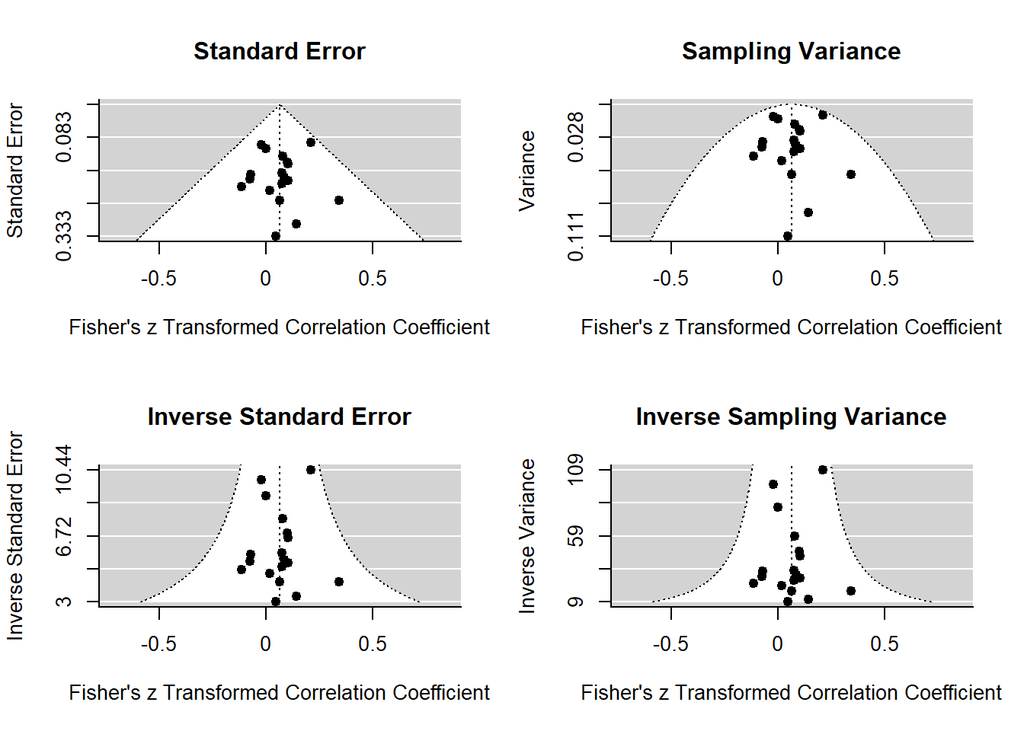

```r
### set up 2x2 array for plotting
par(mfrow=c(2,2))

### draw funnel plots
funnel(res_lit, main="Standard Error")
funnel(res_lit, yaxis="vi", main="Sampling Variance")
funnel(res_lit, yaxis="seinv", main="Inverse Standard Error")
funnel(res_lit, yaxis="vinv", main="Inverse Sampling Variance")
```

```r
dev.off()
```

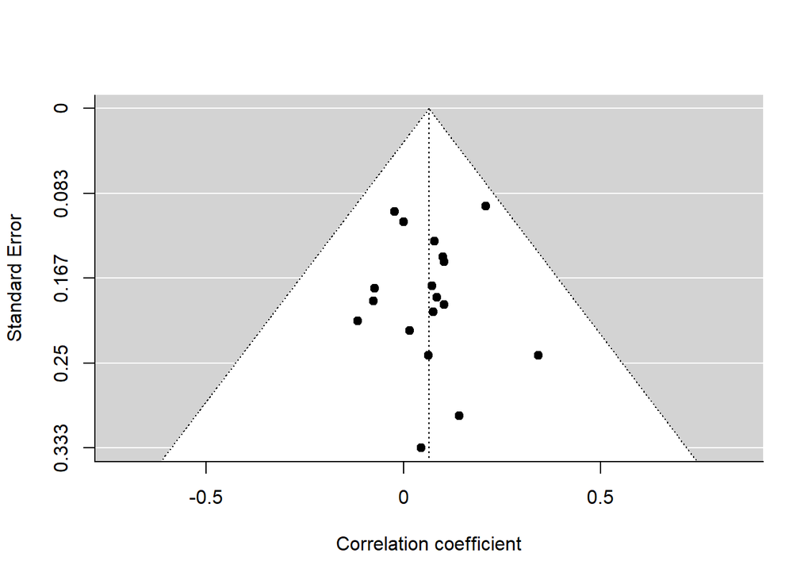

```r
### funnel plot
funnel(res_lit, xlab = "Correlation coefficient")
```

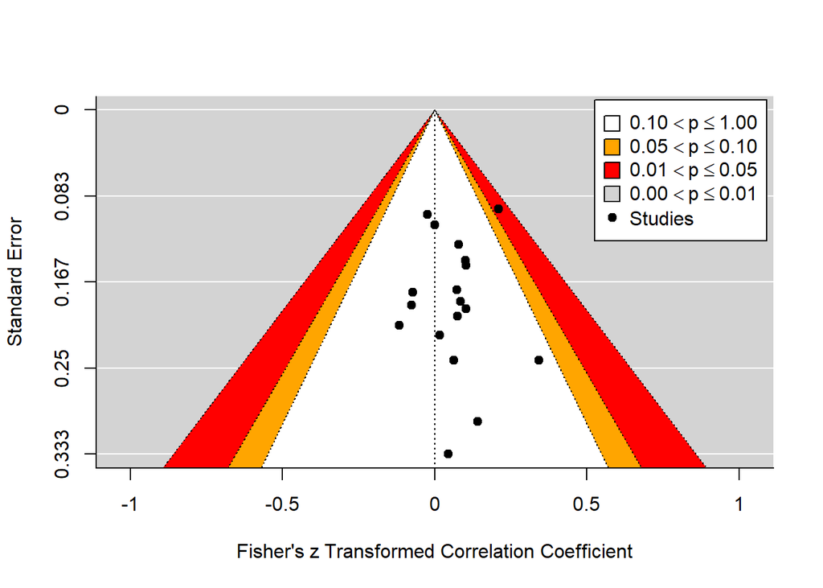

```r
### create contour enhanced funnel plot (with funnel centered at 0)
funnel(res_lit, level=c(90, 95, 99), shade=c("white", "orange", "red"), refline=0, legend = TRUE)
```

### PET - PEESE

```r
regtest(res_lit)
```

```
##
## Regression Test for Funnel Plot Asymmetry
##
## Model:     mixed-effects meta-regression model
## Predictor: standard error
##
## Test for Funnel Plot Asymmetry: z = -0.1580, p = 0.8745
## Limit Estimate (as sei -> 0):   b = 0.0816 (CI: -0.1414, 0.3047)
```

```r
regtest(res_lit, predictor="vi") # PEESE
```

```
##
## Regression Test for Funnel Plot Asymmetry
##
## Model:     mixed-effects meta-regression model
## Predictor: sampling variance
##
## Test for Funnel Plot Asymmetry: z = -0.0394, p = 0.9685
## Limit Estimate (as vi -> 0):    b = 0.0667 (CI: -0.0561, 0.1894)
```

### Ranktest

```r
ranktest(res_lit, exact = FALSE)
```

```
##
## Rank Correlation Test for Funnel Plot Asymmetry
##
## Kendall's tau = -0.0262, p = 0.8795
```

### Outlier/influential points detection

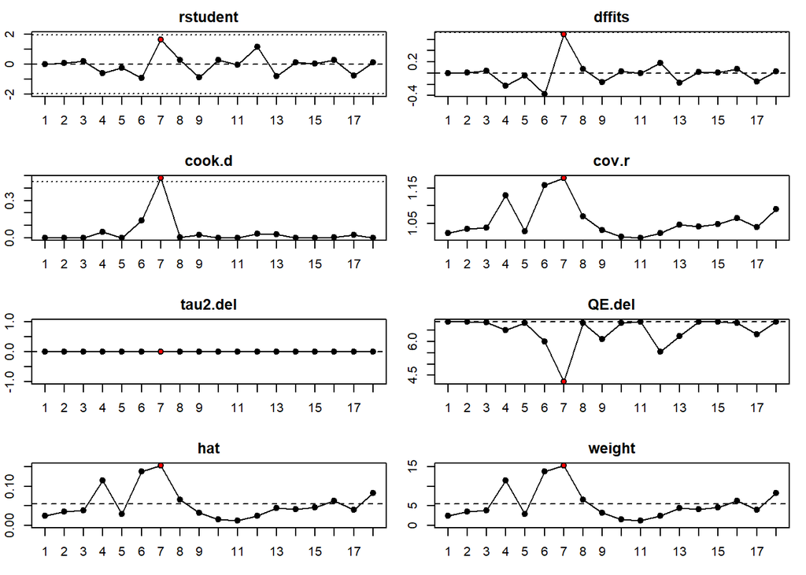

```r
### calculate influence diagnostics
inf_lit <- influence(res_lit)

### plot the influence diagnostics
plot(inf_lit)
```

## Literacy Model with dependencies

```r
# Overall model with dependencies: general model

intercept.lit.model <- robu(formula = yi ~ 1, data = Data_literacy,
                       studynum = Study, var.eff.size = vi,
                       rho = .8, small = TRUE)

print(intercept.lit.model)
```

```
## RVE: Correlated Effects Model with Small-Sample Corrections
##
## Model: yi ~ 1
##
## Number of studies = 18
## Number of outcomes = 155 (min = 2 , mean = 8.61 , median = 6 , max = 42 )
## Rho = 0.8
## I.sq = 29.47581
## Tau.sq = 0.01140788
##
##                Estimate StdErr t-value  dfs P(|t|>) 95% CI.L 95% CI.U Sig
## 1 X.Intercept.   0.0495 0.0217    2.29 13.5  0.0391  0.00288   0.0961  **
## ---
## Signif. codes: < .01 *** < .05 ** < .10 *
## ---
## Note: If df < 4, do not trust the results
```

```r
sensitivity(intercept.lit.model)
```

```
## RVE: Correlated Effects Model with Small-Sample Corrections
## Model: yi ~ 1
##
## Sensitivity Analysis
##
##                           Rho = 0 Rho = 0.2 Rho = 0.4 Rho = 0.6 Rho = 0.8
##  X.Intercept. Coefficient 0.0496  0.0495    0.0495    0.0495    0.0495
##               Std. Error  0.0218  0.0218    0.0217    0.0217    0.0217
##  Tau.sq       Estimate    0.0105  0.0107    0.0109    0.0112    0.0114
##  Rho = 1
##  0.0495
##  0.0216
##  0.0116
```

### Forest plot

```r
pdf(file = "forestplot_lit.pdf", width = 20, height = 28, pointsize = 8)

forest.robu(intercept.lit.model, es.lab = "Component", study.lab = "Study", "Effect Size" = yi)

dev.off()
```

### Diagnostic

#### Egger’s regression test/ PET-PEESE procedure

```r
# with un-corrected ES (PET) - use standard error as predictor
PET_lit <- robu(formula = yi ~ sei, data = Data_literacy,
                       studynum = Study, var.eff.size = vi,
                       rho = .8, small = TRUE)
print(PET_lit)
```

```
## RVE: Correlated Effects Model with Small-Sample Corrections
##
## Model: yi ~ sei
##
## Number of studies = 18
## Number of outcomes = 155 (min = 2 , mean = 8.61 , median = 6 , max = 42 )
## Rho = 0.8
## I.sq = 32.62041
## Tau.sq = 0.01351139
##
##                Estimate StdErr t-value  dfs P(|t|>) 95% CI.L 95% CI.U Sig
## 1 X.Intercept.   0.0461 0.0752  0.6138 6.64   0.560   -0.134    0.226
## 2          sei   0.0198 0.3934  0.0504 8.61   0.961   -0.876    0.916
## ---
## Signif. codes: < .01 *** < .05 ** < .10 *
## ---
## Note: If df < 4, do not trust the results
```

```r
# with un-corrected ES (PEESE) - use variance as predictor
PEESE_lit <- robu(formula = yi ~ vi, data = Data_literacy,
                       studynum = Study, var.eff.size = vi,
                       rho = .8, small = TRUE)
print(PEESE_lit)
```

```
## RVE: Correlated Effects Model with Small-Sample Corrections
##
## Model: yi ~ vi
##
## Number of studies = 18
## Number of outcomes = 155 (min = 2 , mean = 8.61 , median = 6 , max = 42 )
## Rho = 0.8
## I.sq = 32.38901
## Tau.sq = 0.01318067
##
##                Estimate StdErr t-value  dfs P(|t|>) 95% CI.L 95% CI.U Sig
## 1 X.Intercept.   0.0442 0.0378   1.167 7.35    0.28  -0.0444    0.133
## 2           vi   0.1705 0.8089   0.211 6.34    0.84  -1.7837    2.125
## ---
## Signif. codes: < .01 *** < .05 ** < .10 *
## ---
## Note: If df < 4, do not trust the results
```

### Moderators

#### Literacy model - Group as predictor

```r
lit.group <- robu(formula = yi ~ 0 + Group, data = Data_literacy, studynum = Study, var.eff.size = vi,
                       rho = .8, small = TRUE)
print(lit.group)
```

```
## RVE: Correlated Effects Model with Small-Sample Corrections
##
## Model: yi ~ 0 + Group
##
## Number of studies = 18
## Number of outcomes = 155 (min = 2 , mean = 8.61 , median = 6 , max = 42 )
## Rho = 0.8
## I.sq = 32.05612
## Tau.sq = 0.01302584
##
##            Estimate StdErr t-value  dfs P(|t|>) 95% CI.L 95% CI.U Sig
## 1  GroupDD   0.0802 0.0648   1.237 7.30   0.254  -0.0718    0.232
## 2 GroupDLD   0.0538 0.0685   0.786 2.79   0.493  -0.1736    0.281
## 3  GroupTD   0.0375 0.0304   1.230 9.25   0.249  -0.0311    0.106
## ---
## Signif. codes: < .01 *** < .05 ** < .10 *
## ---
## Note: If df < 4, do not trust the results
```

```r
sensitivity(lit.group)
```

```
## RVE: Correlated Effects Model with Small-Sample Corrections
## Model: yi ~ 0 + Group
##
## Sensitivity Analysis
##
##                       Rho = 0 Rho = 0.2 Rho = 0.4 Rho = 0.6 Rho = 0.8 Rho = 1
##  GroupDD  Coefficient 0.0808  0.0806    0.0805    0.0804    0.0802    0.0801
##           Std. Error  0.0649  0.0649    0.0648    0.0648    0.0648    0.0648
##  GroupDLD Coefficient 0.0532  0.0533    0.0535    0.0536    0.0538    0.0539
##           Std. Error  0.0684  0.0684    0.0685    0.0685    0.0685    0.0685
##  GroupTD  Coefficient 0.0377  0.0376    0.0376    0.0375    0.0375    0.0374
##           Std. Error  0.0309  0.0308    0.0307    0.0305    0.0304    0.0304
##  Tau.sq   Estimate    0.0113  0.0118    0.0122    0.0126    0.0130    0.0134
```

```r
#test overall component effect (i.e. do estimates differ from zero)
Wald_test(lit.group, constraints = matrix(c(1,0,0,0,1,0,0,0,1),3,3), vcov = "CR2")
```

```
##  test Fstat df_num df_denom p_val sig
##   HTZ   1.3      3     6.92 0.347
```

```r
#run comparisons between groups (i.e. do estimates differ from each other)
V_lit.group <- vcovCR(lit.group, type = "CR2")
Wald_test(lit.group, constraints = constrain_equal(1:3), vcov = V_lit.group)
```

```
##  test Fstat df_num df_denom p_val sig
##   HTZ 0.127      2     6.13 0.883
```

#### Literacy model - Component as predictor

```r
# Overall model with dependencies: general model
table(Data_literacy$Component, Data_literacy$Variable)
```

```
##
##                         Literacy
##   Composite                    6
##   Reading                    132
##   Reading comprehension        4
##   Spelling                    13
```

```r
lit.component <- robu(formula = yi ~ 0 + Component, data = Data_literacy[Data_literacy$Component == 'Reading'| Data_literacy$Component == "Spelling",], studynum = Study, var.eff.size = vi,
                       rho = .8, small = TRUE)
print(lit.component)
```

```
## RVE: Correlated Effects Model with Small-Sample Corrections
##
## Model: yi ~ 0 + Component
##
## Number of studies = 16
## Number of outcomes = 145 (min = 2 , mean = 9.06 , median = 6 , max = 42 )
## Rho = 0.8
## I.sq = 14.16649
## Tau.sq = 0.004928424
##
##                     Estimate StdErr t-value  dfs P(|t|>) 95% CI.L 95% CI.U Sig
## 1  ComponentReading   0.0503 0.0268    1.88 9.50  0.0911 -0.00975     0.11   *
## 2 ComponentSpelling   0.1199 0.0737    1.63 3.75  0.1840 -0.09038     0.33
## ---
## Signif. codes: < .01 *** < .05 ** < .10 *
## ---
## Note: If df < 4, do not trust the results
```

```r
sensitivity(lit.component)
```

```
## RVE: Correlated Effects Model with Small-Sample Corrections
## Model: yi ~ 0 + Component
##
## Sensitivity Analysis
##
##                                Rho = 0 Rho = 0.2 Rho = 0.4 Rho = 0.6 Rho = 0.8
##  ComponentReading  Coefficient 0.05168 0.05130   0.05095   0.05061   0.05029
##                    Std. Error  0.02783 0.02754   0.02726   0.02700   0.02675
##  ComponentSpelling Coefficient 0.11929 0.11944   0.11959   0.11973   0.11988
##                    Std. Error  0.07307 0.07324   0.07340   0.07356   0.07372
##  Tau.sq            Estimate    0.00325 0.00367   0.00409   0.00451   0.00493
##  Rho = 1
##  0.04998
##  0.02652
##  0.12002
##  0.07387
##  0.00535
```

```r
#test overall component effect (i.e. do estimates differ from zero)
Wald_test(lit.component, constraints = matrix(c(1,0,0,1),2,2), vcov = "CR2")
```

```
##  test Fstat df_num df_denom p_val sig
##   HTZ  2.56      2     6.25 0.154
```

```r
#run comparisons between components (i.e. do estimates differ from each other)
V_lit.component <- vcovCR(lit.component, type = "CR2")
Wald_test(lit.component, constraints = constrain_equal(1:2), vcov = V_lit.component)
```

```
##  test Fstat df_num df_denom p_val sig
##   HTZ 0.809      1     4.67 0.412
```

#### Literacy model - Age

```r
# Overall model with dependencies: general model


lit.age <- robu(formula = yi ~ Age, data = Data_literacy,
                       studynum = Study, var.eff.size = vi,
                       rho = .8, small = TRUE)
print(lit.age)
```

```
## RVE: Correlated Effects Model with Small-Sample Corrections
##
## Model: yi ~ Age
##
## Number of studies = 18
## Number of outcomes = 155 (min = 2 , mean = 8.61 , median = 6 , max = 42 )
## Rho = 0.8
## I.sq = 32.98804
## Tau.sq = 0.01432718
##
##                Estimate  StdErr t-value  dfs P(|t|>) 95% CI.L 95% CI.U Sig
## 1 X.Intercept. 0.040986 0.06050   0.677 7.88   0.517  -0.0989   0.1809
## 2          Age 0.000608 0.00394   0.154 4.29   0.884  -0.0100   0.0113
## ---
## Signif. codes: < .01 *** < .05 ** < .10 *
## ---
## Note: If df < 4, do not trust the results
```

```r
sensitivity(lit.age)
```

```
## RVE: Correlated Effects Model with Small-Sample Corrections
## Model: yi ~ Age
##
## Sensitivity Analysis
##
##                           Rho = 0  Rho = 0.2 Rho = 0.4 Rho = 0.6 Rho = 0.8
##  X.Intercept. Coefficient 0.042846 0.042361  0.041890  0.041432  0.040986
##               Std. Error  0.061011 0.060874  0.060742  0.060617  0.060497
##  Age          Coefficient 0.000479 0.000513  0.000545  0.000577  0.000608
##               Std. Error  0.003931 0.003933  0.003935  0.003937  0.003940
##  Tau.sq       Estimate    0.012370 0.012859  0.013349  0.013838  0.014327
##  Rho = 1
##  0.040553
##  0.060382
##  0.000638
##  0.003942
##  0.014816
```

#### Literacy model - Sequence complexity

```r
# Overall model with dependencies: general model

lit.seq.complexity <- robu(formula = yi ~ -1 + as.factor(Seq_complexity), data = Data_literacy[Data_literacy$Seq_complexity == "FOC" | Data_literacy$Seq_complexity == "SOC", ],
                       studynum = Study, var.eff.size = vi,
                       rho = .8, small = TRUE)

print(lit.seq.complexity)
```

```
## RVE: Correlated Effects Model with Small-Sample Corrections
##
## Model: yi ~ -1 + as.factor(Seq_complexity)
##
## Number of studies = 16
## Number of outcomes = 125 (min = 2 , mean = 7.81 , median = 6 , max = 42 )
## Rho = 0.8
## I.sq = 37.43416
## Tau.sq = 0.01772421
##
##                                Estimate StdErr t-value  dfs P(|t|>) 95% CI.L
## 1 as.factor.Seq_complexity.FOC   0.0278 0.0286   0.972 4.31  0.3825  -0.0495
## 2 as.factor.Seq_complexity.SOC   0.0687 0.0364   1.886 7.69  0.0975  -0.0159
##   95% CI.U Sig
## 1    0.105
## 2    0.153   *
## ---
## Signif. codes: < .01 *** < .05 ** < .10 *
## ---
## Note: If df < 4, do not trust the results
```

```r
sensitivity(lit.seq.complexity)
```

```
## RVE: Correlated Effects Model with Small-Sample Corrections
## Model: yi ~ -1 + as.factor(Seq_complexity)
##
## Sensitivity Analysis
##
##                                           Rho = 0 Rho = 0.2 Rho = 0.4 Rho = 0.6
##  as.factor.Seq_complexity.FOC Coefficient 0.0282  0.0281    0.0280    0.0279
##                               Std. Error  0.0286  0.0286    0.0286    0.0286
##  as.factor.Seq_complexity.SOC Coefficient 0.0688  0.0688    0.0687    0.0687
##                               Std. Error  0.0368  0.0367    0.0366    0.0365
##  Tau.sq                       Estimate    0.0152  0.0159    0.0165    0.0171
##  Rho = 0.8 Rho = 1
##  0.0278    0.0277
##  0.0286    0.0287
##  0.0687    0.0687
##  0.0364    0.0364
##  0.0177    0.0183
```

```r
#test overall sequence complexity effect (i.e. do estimates differ from zero)
Wald_test(lit.seq.complexity, constraints = matrix(c(1,0,0,1),2,2), vcov = "CR2", tidy = TRUE)
```

```
##  test Fstat df_num df_denom p_val sig
##   HTZ  2.22      2     7.22 0.177
```

```r
#run pairwise comparisons between sequence complexity  (i.e. do estimates differ from each other)
Wald_test(lit.seq.complexity, constraints = constrain_equal(c(1,2)), vcov = "CR2", tidy = TRUE)
```

```
##  test Fstat df_num df_denom p_val sig
##   HTZ 0.692      1     8.79 0.427
```

#### Literacy model - Session

```r
# Overall model with dependencies: general model

table(Data_literacy$Time, Data_literacy$Variable) # third session is removed as there are not enough effect sizes
```

```
##
##     Literacy
##   1      115
##   2       37
##   3        3
```

```r
lit.session <- robu(formula = yi ~ Time-1, data = Data_literacy[Data_literacy$Time != 3,],
                       studynum = Study, var.eff.size = vi,
                       rho = .8, small = TRUE)
print(lit.session)
```

```
## RVE: Correlated Effects Model with Small-Sample Corrections
##
## Model: yi ~ Time - 1
##
## Number of studies = 18
## Number of outcomes = 152 (min = 2 , mean = 8.44 , median = 6 , max = 42 )
## Rho = 0.8
## I.sq = 21.6928
## Tau.sq = 0.007680435
##
##         Estimate StdErr t-value   dfs P(|t|>) 95% CI.L 95% CI.U Sig
## 1 Time1   0.0228 0.0241   0.947 12.80  0.3614  -0.0293   0.0748
## 2 Time2   0.1644 0.0451   3.646  3.67  0.0253   0.0347   0.2941  **
## ---
## Signif. codes: < .01 *** < .05 ** < .10 *
## ---
## Note: If df < 4, do not trust the results
```

```r
sensitivity(lit.session)
```

```
## RVE: Correlated Effects Model with Small-Sample Corrections
## Model: yi ~ Time - 1
##
## Sensitivity Analysis
##
##                     Rho = 0 Rho = 0.2 Rho = 0.4 Rho = 0.6 Rho = 0.8 Rho = 1
##  Time1  Coefficient 0.02226 0.02239   0.02252   0.02264   0.02277   0.02288
##         Std. Error  0.02424 0.02419   0.02414   0.02409   0.02405   0.02401
##  Time2  Coefficient 0.16577 0.16541   0.16506   0.16471   0.16437   0.16404
##         Std. Error  0.04520 0.04516   0.04513   0.04511   0.04508   0.04505
##  Tau.sq Estimate    0.00658 0.00686   0.00713   0.00741   0.00768   0.00795
```

```r
#test overall session effect (i.e. do estimates differ from zero)
Wald_test(lit.session, constraints = matrix(c(1,0,0,1),2,2), vcov = "CR2", tidy = TRUE)
```

```
##  test Fstat df_num df_denom  p_val sig
##   HTZ  5.89      2     6.36 0.0357   *
```

```r
#run pairwise comparisons between sessions (i.e. do estimates differ from each other)
Wald_test(lit.session, constraints = constrain_equal(1:2), vcov = "CR2", tidy = TRUE)
```

```
##  test Fstat df_num df_denom  p_val sig
##   HTZ   8.4      1     5.13 0.0329   *
```

#### Literacy model - number of trials

```r
# Overall model with dependencies: general model


lit.trials <- robu(formula = yi ~ Trial_no, data = Data_literacy,
                       studynum = Study, var.eff.size = vi,
                       rho = .8, small = TRUE)
print(lit.trials)
```

```
## RVE: Correlated Effects Model with Small-Sample Corrections
##
## Model: yi ~ Trial_no
##
## Number of studies = 18
## Number of outcomes = 155 (min = 2 , mean = 8.61 , median = 6 , max = 42 )
## Rho = 0.8
## I.sq = 28.48279
## Tau.sq = 0.01121905
##
##                 Estimate    StdErr t-value   dfs P(|t|>)   95% CI.L 95% CI.U
## 1 X.Intercept. 0.0142895 0.0323961   0.441 10.26   0.668 -0.0576482 0.086227
## 2     Trial_no 0.0000427 0.0000382   1.118  5.28   0.312 -0.0000539 0.000139
##   Sig
## 1
## 2
## ---
## Signif. codes: < .01 *** < .05 ** < .10 *
## ---
## Note: If df < 4, do not trust the results
```

```r
sensitivity(lit.trials)
```

```
## RVE: Correlated Effects Model with Small-Sample Corrections
## Model: yi ~ Trial_no
##
## Sensitivity Analysis
##
##                           Rho = 0  Rho = 0.2 Rho = 0.4 Rho = 0.6 Rho = 0.8
##  X.Intercept. Coefficient 1.30e-02 1.33e-02  1.37e-02  1.40e-02  1.43e-02
##               Std. Error  3.26e-02 3.25e-02  3.25e-02  3.24e-02  3.24e-02
##  Trial_no     Coefficient 4.43e-05 4.39e-05  4.35e-05  4.31e-05  4.27e-05
##               Std. Error  3.89e-05 3.87e-05  3.85e-05  3.84e-05  3.82e-05
##  Tau.sq       Estimate    9.48e-03 9.92e-03  1.04e-02  1.08e-02  1.12e-02
##  Rho = 1
##  1.46e-02
##  3.24e-02
##  4.23e-05
##  3.80e-05
##  1.17e-02
```

#### Literacy model - Type of sequence

```r
# Overall model with dependencies: general model

lit.seq.type <- robu(formula = yi ~ -1 + as.factor(Seq_type), data = Data_literacy,
                       studynum = Study, var.eff.size = vi,
                       rho = .8, small = TRUE)
print(lit.seq.type)
```

```
## RVE: Correlated Effects Model with Small-Sample Corrections
##
## Model: yi ~ -1 + as.factor(Seq_type)
##
## Number of studies = 18
## Number of outcomes = 155 (min = 2 , mean = 8.61 , median = 6 , max = 42 )
## Rho = 0.8
## I.sq = 35.61778
## Tau.sq = 0.01604775
##
##                                    Estimate StdErr t-value  dfs P(|t|>)
## 1   as.factor.Seq_type.alternating 0.000902 0.0807  0.0112 1.00  0.9929
## 2 as.factor.Seq_type.deterministic 0.046112 0.0226  2.0407 9.41  0.0703
## 3 as.factor.Seq_type.probabilistic 0.067149 0.0533  1.2588 2.64  0.3080
##   95% CI.L 95% CI.U Sig
## 1 -1.02453   1.0263
## 2 -0.00467   0.0969   *
## 3 -0.11664   0.2509
## ---
## Signif. codes: < .01 *** < .05 ** < .10 *
## ---
## Note: If df < 4, do not trust the results
```

```r
sensitivity(lit.seq.type)
```

```
## RVE: Correlated Effects Model with Small-Sample Corrections
## Model: yi ~ -1 + as.factor(Seq_type)
##
## Sensitivity Analysis
##
##                                               Rho = 0   Rho = 0.2 Rho = 0.4
##  as.factor.Seq_type.alternating   Coefficient -0.000489 -0.000129 0.000222
##                                   Std. Error   0.080172  0.080312 0.080447
##  as.factor.Seq_type.deterministic Coefficient  0.045576  0.045719 0.045855
##                                   Std. Error   0.022286  0.022367 0.022446
##  as.factor.Seq_type.probabilistic Coefficient  0.067859  0.067668 0.067487
##                                   Std. Error   0.054749  0.054368 0.054008
##  Tau.sq                           Estimate     0.012526  0.013406 0.014287
##  Rho = 0.6 Rho = 0.8 Rho = 1
##  0.000566  0.000902  0.00123
##  0.080577  0.080703  0.08082
##  0.045986  0.046112  0.04623
##  0.022522  0.022597  0.02267
##  0.067314  0.067149  0.06699
##  0.053667  0.053343  0.05304
##  0.015167  0.016048  0.01693
```

```r
#test overall SRT type effect (is the estimate for each group different from zero)
Wald_test(lit.seq.type, constraints = matrix(c(1,0,0,0,1,0,0,0,1),3,3), vcov = "CR2", tidy = TRUE)
```

```
##  test Fstat df_num df_denom p_val sig
##   HTZ 0.967      3     2.04 0.543
```

```r
#run comparisons between types of sequence (are the estimates difference from each other)
V_lit.seq.type <- vcovCR(lit.seq.type, type = "CR2")
Wald_test(lit.seq.type, constraints = constrain_equal(1:2), vcov = V_lit.seq.type)
```

```
##  test Fstat df_num df_denom p_val sig
##   HTZ 0.291      1     1.26 0.669
```

### Literacy components - comparison between groups

#### reading model - group as predictor

```r
table(Data_reading$Group, Data_reading$Component)
```

```
##
##       Reading
##   DD       40
##   DLD      19
##   TD       73
```

```r
reading.model <- robu(formula = yi ~ 0 + Group, data = Data_reading,
                       studynum = Study, var.eff.size = vi,
                       rho = .8, small = TRUE)
print(reading.model)
```

```
## RVE: Correlated Effects Model with Small-Sample Corrections
##
## Model: yi ~ 0 + Group
##
## Number of studies = 15
## Number of outcomes = 132 (min = 2 , mean = 8.8 , median = 6 , max = 42 )
## Rho = 0.8
## I.sq = 10.64324
## Tau.sq = 0.003494174
##
##            Estimate StdErr t-value  dfs P(|t|>) 95% CI.L 95% CI.U Sig
## 1  GroupDD   0.0449 0.0753   0.596 5.35   0.576  -0.1449    0.235
## 2 GroupDLD   0.0998 0.0433   2.307 2.70   0.114  -0.0468    0.246
## 3  GroupTD   0.0467 0.0400   1.167 6.73   0.283  -0.0486    0.142
## ---
## Signif. codes: < .01 *** < .05 ** < .10 *
## ---
## Note: If df < 4, do not trust the results
```

```r
sensitivity(reading.model)
```

```
## RVE: Correlated Effects Model with Small-Sample Corrections
## Model: yi ~ 0 + Group
##
## Sensitivity Analysis
##
##                       Rho = 0 Rho = 0.2 Rho = 0.4 Rho = 0.6 Rho = 0.8 Rho = 1
##  GroupDD  Coefficient 0.04774 0.04698   0.04625   0.04554   0.04485   0.0442
##           Std. Error  0.07568 0.07558   0.07548   0.07537   0.07526   0.0751
##  GroupDLD Coefficient 0.09926 0.09940   0.09954   0.09968   0.09981   0.0999
##           Std. Error  0.04291 0.04300   0.04309   0.04318   0.04326   0.0433
##  GroupTD  Coefficient 0.04880 0.04820   0.04765   0.04714   0.04667   0.0462
##           Std. Error  0.04174 0.04125   0.04080   0.04037   0.03997   0.0396
##  Tau.sq   Estimate    0.00148 0.00198   0.00249   0.00299   0.00349   0.0040
```

```r
#test overall group effect (i.e. do estimates differ from zero)
Wald_test(reading.model, constraints = matrix(c(1,0,0,0,1,0,0,0,1),3,3), vcov = "CR2",tidy = TRUE)
```

```
##  test Fstat df_num df_denom p_val sig
##   HTZ  2.12      3     5.56 0.207
```

```r
#run pairwise comparisons between groups (i.e. do estimates differ from each other)
V_reading.model <- vcovCR(reading.model, type = "CR2")
Wald_test(reading.model, constraints = constrain_pairwise(1:3), vcov = V_reading.model)
```

```
## $`GroupDLD - GroupDD`
##  test Fstat df_num df_denom p_val sig
##   HTZ 0.401      1     4.76 0.556
##
## $`GroupTD - GroupDD`
##  test    Fstat df_num df_denom p_val sig
##   HTZ 0.000347      1     7.35 0.986
##
## $`GroupTD - GroupDLD`
##  test Fstat df_num df_denom p_val sig
##   HTZ 0.749      1     3.27 0.446
```

#### spelling model - group as predictor

```r
table(Data_spelling$Group, Data_spelling$Component)
```

```
##
##       Spelling
##   DD         4
##   DLD        1
##   TD         8
```

```r
spelling.model <- robu(formula = yi ~ 0 + Group, data = Data_spelling[Data_spelling$Group != 'DLD',],
                       studynum = Study, var.eff.size = vi,
                       rho = .8, small = TRUE)

print(spelling.model)
```

```
## RVE: Correlated Effects Model with Small-Sample Corrections
##
## Model: yi ~ 0 + Group
##
## Number of studies = 5
## Number of outcomes = 12 (min = 1 , mean = 2.4 , median = 2 , max = 4 )
## Rho = 0.8
## I.sq = 34.43532
## Tau.sq = 0.0167184
##
##           Estimate StdErr t-value  dfs P(|t|>) 95% CI.L 95% CI.U Sig
## 1 GroupDD   0.2519  0.159   1.588 1.84   0.263   -0.489    0.993
## 2 GroupTD   0.0473  0.088   0.537 3.15   0.627   -0.226    0.320
## ---
## Signif. codes: < .01 *** < .05 ** < .10 *
## ---
## Note: If df < 4, do not trust the results
```

```r
sensitivity(spelling.model)
```

```
## RVE: Correlated Effects Model with Small-Sample Corrections
## Model: yi ~ 0 + Group
##
## Sensitivity Analysis
##
##                      Rho = 0 Rho = 0.2 Rho = 0.4 Rho = 0.6 Rho = 0.8 Rho = 1
##  GroupDD Coefficient 0.2527  0.2525    0.2523    0.2521    0.2519    0.2517
##          Std. Error  0.1586  0.1586    0.1586    0.1586    0.1586    0.1586
##  GroupTD Coefficient 0.0470  0.0471    0.0471    0.0472    0.0473    0.0473
##          Std. Error  0.0881  0.0880    0.0880    0.0880    0.0880    0.0880
##  Tau.sq  Estimate    0.0146  0.0152    0.0157    0.0162    0.0167    0.0172
```

```r
#test overall component effect (i.e. do estimates differ from zero)
Wald_test(spelling.model, constraints = matrix(c(1,0,0,1),2,2), vcov = "CR2",tidy = TRUE)
```

```
##  test Fstat df_num df_denom p_val sig
##   HTZ   1.6      2     1.95 0.388
```

```r
#run pairwise comparisons between components (i.e. do estimates differ from each other)
Wald_test(spelling.model, constraints = constrain_equal(1:2), vcov = "CR2", tidy = TRUE)
```

```
##  test Fstat df_num df_denom p_val sig
##   HTZ 0.896      1      2.7 0.421
```

```r
#stargazer(g, z,  type="html", out="models.htm")
```

# Summary table

Disattenuation using Spearman’s formula [@spearman1904]

```r
#res.table <- read_excel("subgroup analysis - correlational meta.xlsx")

#res.table$r <-  apply(res.table["z'"], 1, function(x) ztor(x))

#rxx <- 0.3095069
#res.table$R <-  apply(res.table["r"], 1, function(x) Disat(x, rxx))

#write.csv(res.table, "MA.table.csv")
```

# Session information

sessionInfo()